# Business Statistics End of Term Assessment IB94X0 2023-2024 #1

5504970

```r
library(tidyverse)
library(lubridate)
library(emmeans)
library(gridExtra)
library(Hmisc)
library(car)
library(ggpubr)
options(width=100)
```

# Academic Integrity Declaration

We’re part of an academic community at Warwick. Whether studying, teaching, or researching, we are all taking part in an expert conversation which must meet standards of academic integrity. When we all meet these standards, we can take pride in our own academic achievements, as individuals and as an academic community.

Academic integrity means committing to honesty in academic work, giving credit where we’ve used others’ ideas and being proud of our own achievements.

In submitting my work, I confirm that:

1. I have read the guidance on academic integrity provided in the Student Handbook and understand the University regulations in relation to Academic Integrity. I am aware of the potential consequences of Academic Misconduct.
2. I declare that the work is all my own, except where I have stated otherwise.
3. No substantial part(s) of the work submitted here has also been submitted by me in other credit bearing assessments courses of study (other than in certain cases of a re-submission of a piece of work), and I acknowledge that if this has been done this may lead to an appropriate sanction.
4. Where a generative Artificial Intelligence such as ChatGPT has been used I confirm I have abided by both the University guidance and specific requirements as set out in the Student Handbook and the Assessment brief. I have clearly acknowledged the use of any generative Artificial Intelligence in my submission, my reasoning for using it and which generative AI (or AIs) I have used. Except where indicated the work is otherwise entirely my own.
5. I understand that should this piece of work raise concerns requiring investigation in relation to any of points above, it is possible that other work I have submitted for assessment will be checked, even if marks (provisional or confirmed) have been published.
6. Where a proof-reader, paid or unpaid was used, I confirm that the proof-reader was made aware of and has complied with the University’s proofreading policy.

# Question 1

### Data Dictionary

[output not shown]

This is the list of variables for the data of London bike hires.

### Data Preparation

```r
# Read the data
london.covid.bikes <- read_csv('London_COVID_bikes.csv')
```

We read the dataset of bike hires in London.

```r
# Use summary to check if there is anomaly in the data and see the distribution of values
summary(london.covid.bikes)
```

```
##       date                Hires       schools_closed     pubs_closed       shops_closed
##  Min.   :2010-07-30   Min.   :    0   Min.   :0.00000   Min.   :0.00000   Min.   :0.00000
##  1st Qu.:2013-11-13   1st Qu.:19776   1st Qu.:0.00000   1st Qu.:0.00000   1st Qu.:0.00000
##  Median :2017-02-28   Median :26356   Median :0.00000   Median :0.00000   Median :0.00000
##  Mean   :2017-02-28   Mean   :26607   Mean   :0.02743   Mean   :0.05175   Mean   :0.04634
##  3rd Qu.:2020-06-15   3rd Qu.:33481   3rd Qu.:0.00000   3rd Qu.:0.00000   3rd Qu.:0.00000
##  Max.   :2023-09-30   Max.   :73094   Max.   :1.00000   Max.   :1.00000   Max.   :1.00000
##  eating_places_closed  stay_at_home     household_mixing_indoors_banned      wfh
##  Min.   :0.00000      Min.   :0.00000   Min.   :0.00000                 Min.   :0.0000
##  1st Qu.:0.00000      1st Qu.:0.00000   1st Qu.:0.00000                 1st Qu.:0.0000
##  Median :0.00000      Median :0.00000   Median :0.00000                 Median :0.0000
##  Mean   :0.05175      Mean   :0.03616   Mean   :0.06525                 Mean   :0.2273
##  3rd Qu.:0.00000      3rd Qu.:0.00000   3rd Qu.:0.00000                 3rd Qu.:0.0000
##  Max.   :1.00000      Max.   :1.00000   Max.   :1.00000                 Max.   :1.0000
##  rule_of_6_indoors     curfew        eat_out_to_help_out     day               month
##  Min.   :0.00000   Min.   :0.00000   Min.   :0.000000    Length:4812        Length:4812
##  1st Qu.:0.00000   1st Qu.:0.00000   1st Qu.:0.000000    Class :character   Class :character
##  Median :0.00000   Median :0.00000   Median :0.000000    Mode  :character   Mode  :character
##  Mean   :0.01995   Mean   :0.01164   Mean   :0.005819
##  3rd Qu.:0.00000   3rd Qu.:0.00000   3rd Qu.:0.000000
##  Max.   :1.00000   Max.   :1.00000   Max.   :1.000000
##       year
##  Min.   :2010
##  1st Qu.:2013
##  Median :2017
##  Mean   :2017
##  3rd Qu.:2020
##  Max.   :2023
```

```r
str(london.covid.bikes)
```

```
## spc_tbl_ [4,812 × 15] (S3: spec_tbl_df/tbl_df/tbl/data.frame)
##  $ date                           : Date[1:4812], format: "2010-07-30" "2010-07-31" "2010-08-01" ...
##  $ Hires                          : num [1:4812] 6897 5564 4303 6642 7966 ...
##  $ schools_closed                 : num [1:4812] 0 0 0 0 0 0 0 0 0 0 ...
##  $ pubs_closed                    : num [1:4812] 0 0 0 0 0 0 0 0 0 0 ...
##  $ shops_closed                   : num [1:4812] 0 0 0 0 0 0 0 0 0 0 ...
##  $ eating_places_closed           : num [1:4812] 0 0 0 0 0 0 0 0 0 0 ...
##  $ stay_at_home                   : num [1:4812] 0 0 0 0 0 0 0 0 0 0 ...
##  $ household_mixing_indoors_banned: num [1:4812] 0 0 0 0 0 0 0 0 0 0 ...
##  $ wfh                            : num [1:4812] 0 0 0 0 0 0 0 0 0 0 ...
##  $ rule_of_6_indoors              : num [1:4812] 0 0 0 0 0 0 0 0 0 0 ...
##  $ curfew                         : num [1:4812] 0 0 0 0 0 0 0 0 0 0 ...
##  $ eat_out_to_help_out            : num [1:4812] 0 0 0 0 0 0 0 0 0 0 ...
##  $ day                            : chr [1:4812] "Fri" "Sat" "Sun" "Mon" ...
##  $ month                          : chr [1:4812] "Jul" "Jul" "Aug" "Aug" ...
##  $ year                           : num [1:4812] 2010 2010 2010 2010 2010 2010 2010 2010 2010 2010 ...
##  - attr(*, "spec")=
##   .. cols(
##   ..   date = col_date(format = ""),
##   ..   Hires = col_double(),
##   ..   schools_closed = col_double(),
##   ..   pubs_closed = col_double(),
##   ..   shops_closed = col_double(),
##   ..   eating_places_closed = col_double(),
##   ..   stay_at_home = col_double(),
##   ..   household_mixing_indoors_banned = col_double(),
##   ..   wfh = col_double(),
##   ..   rule_of_6_indoors = col_double(),
##   ..   curfew = col_double(),
##   ..   eat_out_to_help_out = col_double(),
##   ..   day = col_character(),
##   ..   month = col_character(),
##   ..   year = col_double()
##   .. )
##  - attr(*, "problems")=<externalptr>
```

We check the type of data using summary and str function.

```r
# Set the correct measurement level of data types
col <- c('wfh', 'rule_of_6_indoors', 'eat_out_to_help_out', 'day', 'month', 'year')
london.covid.bikes[col] <- lapply(london.covid.bikes[col], as.factor)
```

We convert the data type of variables ‘wfh’, ‘rule_of_6_indoors’, ‘eat_out_to_help_out’, ‘day’, ‘month’, and ‘year’ to factor, so that they can be used for later analysis and plotting.

```r
# Check if there is any missing value
colSums(is.na(london.covid.bikes))
```

```
##                            date                           Hires                  schools_closed
##                               0                               0                               0
##                     pubs_closed                    shops_closed            eating_places_closed
##                               0                               0                               0
##                    stay_at_home household_mixing_indoors_banned                             wfh
##                               0                               0                               0
##               rule_of_6_indoors                          curfew             eat_out_to_help_out
##                               0                               0                               0
##                             day                           month                            year
##                               0                               0                               0
```

```r
# Find duplicated values in the selected column
column_to_check <- "date"

duplicated_values <- london.covid.bikes[london.covid.bikes$date %in% london.covid.bikes[duplicated(london.covid.bikes$date) | duplicated(london.covid.bikes$date, fromLast = TRUE), ]$date, column_to_check]

print(duplicated_values)
```

```
## # A tibble: 2 × 1
##   date
##   <date>
## 1 2021-12-13
## 2 2021-12-13
```

```r
# Find rows with duplicated values
column_to_check <- "date"
value_to_find <- "2021-12-13"

specific_row <- london.covid.bikes[london.covid.bikes[, column_to_check] == value_to_find, ]

print(specific_row)
```

```
## # A tibble: 2 × 15
##   date       Hires schools_closed pubs_closed shops_closed eating_places_closed stay_at_home
##   <date>     <dbl>          <dbl>       <dbl>        <dbl>                <dbl>        <dbl>
## 1 2021-12-13 25050              0           0            0                    0            0
## 2 2021-12-13 25050              0           0            0                    0            0
## # ℹ 8 more variables: household_mixing_indoors_banned <dbl>, wfh <fct>, rule_of_6_indoors <fct>,
## #   curfew <dbl>, eat_out_to_help_out <fct>, day <fct>, month <fct>, year <fct>
```

```r
# Remove one of the duplicated rows
value.to.remove.in.date <- "2021-12-13"
value.to.remove.in.wfh <- 0

# Remove the specific row based on values in two different columns
london.covid.bikes <- london.covid.bikes[!(london.covid.bikes$date == value.to.remove.in.date & london.covid.bikes$wfh == value.to.remove.in.wfh), ]
```

After doing some checking on the data, it is found that there is no missing value in the dataset but there are duplicated rows with the same date (2021-12-13). We remove one of the row where wfh = 0 since by seeing the pattern of the, it seems to be a minor data entry error and wfh should be 1.

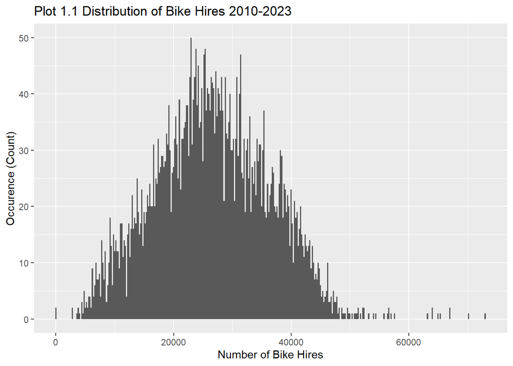

```r
# Using histogram to check if the distribution of the data is normal or not
ggplot(london.covid.bikes) + geom_histogram(aes(Hires), binwidth=200) + labs(title='Plot 1.1 Distribution of Bike Hires 2010-2023', x='Number of Bike Hires', y='Occurence (Count)')
```

Plot 1.1 tells us that the number of bike hires is roughly normally distributed, with a a few outliers occurs. We may remove some of the outliers to make the data more normally distributed for the purpose of better analysis result.

```r
# Remove outliers from the data
london.covid.bikes <- london.covid.bikes[london.covid.bikes$Hires <= 60000, ]
```

We remove data of number of bike hires with value > 60000.

### Data Analysis Using Time Series Plot

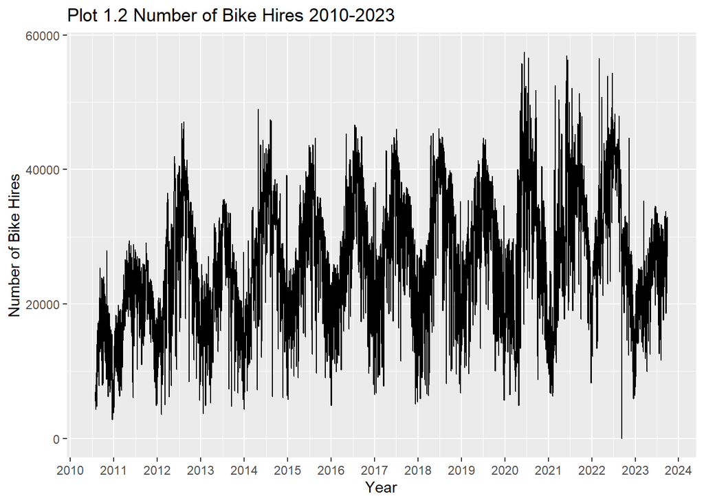

```r
# Plot the number of bike hires as time series
ggplot(london.covid.bikes, aes(x=date, y=Hires)) + geom_line() + scale_x_date(date_breaks = "1 years", date_labels="%Y") + labs(title='Plot 1.2 Number of Bike Hires 2010-2023', x='Year', y='Number of Bike Hires')
```

As per Plot 1.2, the number of bike hires has some certain patterns. In 2010 - 2015 the number of bike hires seems to have upward trend but in 2015-2019 the trend seems to be flat or constant. Upward trend is seen again in 2020-2022 but there is a drastic drop of number of bike hires in 2023.

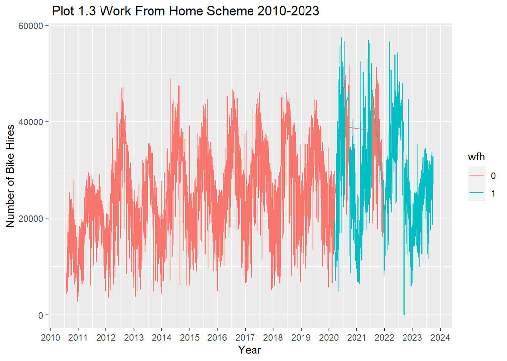

```r
# Plot the Work From Home (wfh) scheme as time series
ggplot(london.covid.bikes, aes(x=date, y=Hires)) + geom_line(aes(color=wfh)) + scale_x_date(date_breaks = "1 years", date_labels = "%Y") + labs(title=' Plot 1.3 Work From Home Scheme 2010-2023', x='Year', y='Number of Bike Hires')
```

In Plot 1.3, we can see that the Work From Home (wfh) scheme started to apply in 2020 onwards (blue colour), which is around March 2020 as a respond to the COVID-19 pandemic.

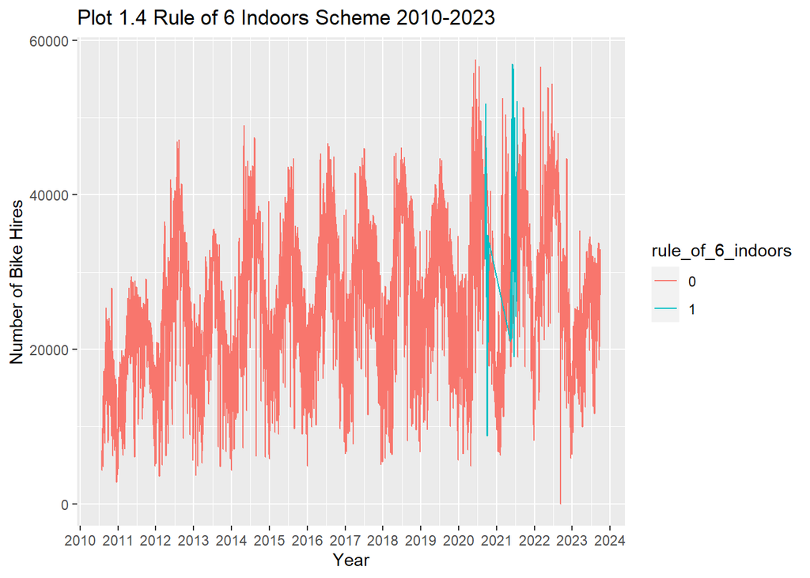

```r
# Plot the Rule of 6 Indoors scheme as time series
ggplot(london.covid.bikes, aes(x=date, y=Hires)) + geom_line(aes(color=rule_of_6_indoors)) + scale_x_date(date_breaks = "1 years", date_labels = "%Y") + labs(title='Plot 1.4 Rule of 6 Indoors Scheme 2010-2023', x='Year', y='Number of Bike Hires')
```

Rule of 6 Indoor was also applied when COVID-19 pandemic occurred. It seem Rule of 6 Indoors scheme only happened in 2020 - 2021 as shown in Plot 1.4 (blue colour).

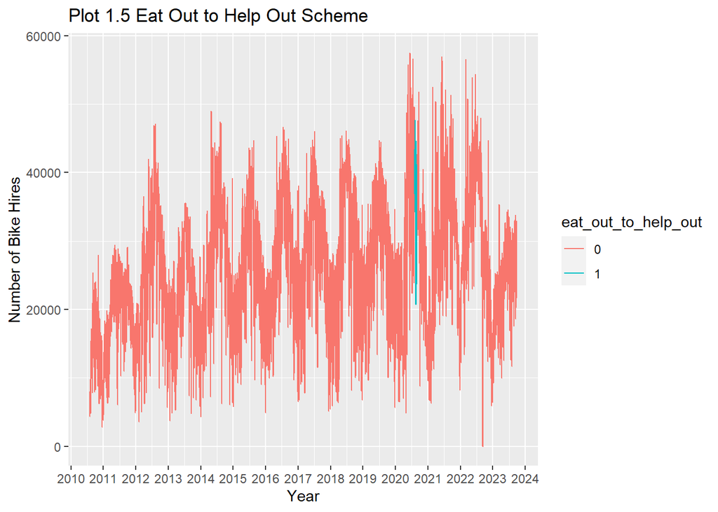

```r
# Plot the Eat Out to Help Out scheme as time series
ggplot(london.covid.bikes, aes(x=date, y=Hires)) + geom_line(aes(color=eat_out_to_help_out)) + scale_x_date(date_breaks = "1 years", date_labels = "%Y") + labs(title='Plot 1.5 Eat Out to Help Out Scheme', x='Year', y='Number of Bike Hires')
```

Eat Out to Help Out scheme was applied in the shortest period of time among the other 2 schemes. From Plot 1.5, we can see that Eat Out to Help Out scheme was only implemented in 2020 (blue colour).

### Correlation and Regression Model without Time Variables

```r
# Use Pearson correlation matrix to show the correlation between each pair of variables (correlation coefficient and p-value)
rcorr(as.matrix(select(london.covid.bikes, Hires, wfh, rule_of_6_indoors, eat_out_to_help_out)))
```

```
##                     Hires   wfh rule_of_6_indoors eat_out_to_help_out
## Hires                1.00  0.07              0.14                0.08
## wfh                  0.07  1.00              0.24               -0.04
## rule_of_6_indoors    0.14  0.24              1.00               -0.01
## eat_out_to_help_out  0.08 -0.04             -0.01                1.00
##
## n= 4802
##
##
## P
##                     Hires  wfh    rule_of_6_indoors eat_out_to_help_out
## Hires                      0.0000 0.0000            0.0000
## wfh                 0.0000        0.0000            0.0041
## rule_of_6_indoors   0.0000 0.0000                   0.4486
## eat_out_to_help_out 0.0000 0.0041 0.4486
```

Since the data of bike hires is normally distributed, we use Pearson correlation matrix to check the correlation between wfh, rule_of_6_indoors and eat_out_to_help_out is significant under NHST, which means the r-value is not zero. It is shown that wfh, rule_of_6_indoors and eat_out_to_help_out have a quite low r value, where wfh vs. rule_of_6_indoors has r-value = 0.24 (5.76% shared variance), wfh vs. eat_out_to_help_out has r-value = -0.04 (0.16% shared variance), and rule_of_6_indoors vs. eat_out_to_help_out has r-value = -0.01 (0.01 shared variance). This information suggests that we shouldn’t have any problems with multicollinearity if we use those 3 schemes as predictors in a multiple regression.

```r
# Simple linear regression for number of bike hires as a function of Work From Home (wfh) scheme
m.hires.by.wfh <- lm(Hires~wfh, data=london.covid.bikes)
summary(m.hires.by.wfh)
```

```
##
## Call:
## lm(formula = Hires ~ wfh, data = london.covid.bikes)
##
## Residuals:
##      Min       1Q   Median       3Q      Max
## -27729.6  -6755.1   -221.2   6894.3  29786.4
##
## Coefficients:
##             Estimate Std. Error t value Pr(>|t|)
## (Intercept)  26182.7      156.3 167.478  < 2e-16 ***
## wfh1          1546.9      328.6   4.708 2.57e-06 ***
## ---
## Signif. codes:  0 '***' 0.001 '**' 0.01 '*' 0.05 '.' 0.1 ' ' 1
##
## Residual standard error: 9529 on 4800 degrees of freedom
## Multiple R-squared:  0.004596,   Adjusted R-squared:  0.004389
## F-statistic: 22.16 on 1 and 4800 DF,  p-value: 2.575e-06
```

```r
cbind(coef(m.hires.by.wfh), confint(m.hires.by.wfh))
```

```
##                           2.5 %    97.5 %
## (Intercept) 26182.675 25876.186 26489.163
## wfh1         1546.929   902.744  2191.114
```

The simple linear regression model between number of bike hires and wfh scheme shows us that for every 1 day of wfh is applied, 1546 more units of bike are rented (t(4800) = 4.71, p<0.001, CI [902.74, 2191.11]).

```r
# Simple linear regression regression for bike hires as a function of Rule of 6 Indoors scheme
m.hires.by.rule_of_6_indoors <- lm(Hires~rule_of_6_indoors, data=london.covid.bikes)
summary(m.hires.by.rule_of_6_indoors)
```

```
##
## Call:
## lm(formula = Hires ~ rule_of_6_indoors, data = london.covid.bikes)
##
## Residuals:
##      Min       1Q   Median       3Q      Max
## -26952.3  -6749.5   -197.2   6846.3  31170.8
##
## Coefficients:
##                    Estimate Std. Error t value Pr(>|t|)
## (Intercept)         26345.2      137.9 191.047   <2e-16 ***
## rule_of_6_indoors1   9386.1      975.3   9.624   <2e-16 ***
## ---
## Signif. codes:  0 '***' 0.001 '**' 0.01 '*' 0.05 '.' 0.1 ' ' 1
##
## Residual standard error: 9460 on 4800 degrees of freedom
## Multiple R-squared:  0.01893,    Adjusted R-squared:  0.01873
## F-statistic: 92.62 on 1 and 4800 DF,  p-value: < 2.2e-16
```

```r
cbind(coef(m.hires.by.rule_of_6_indoors), confint(m.hires.by.rule_of_6_indoors))
```

```
##                                 2.5 %   97.5 %
## (Intercept)        26345.20 26074.856 26615.55
## rule_of_6_indoors1  9386.07  7474.046 11298.10
```

The simple linear regression model between number of bike hire and Rule of 6 Indoors scheme shows us that for every 1 day of Rule of 6 Indoors is applied, 9386 more units of bike are rented (t(4800) = 9.62, p<0.001, CI [7474.05, 11298.10]).

```r
# Simple linear regression regression for bike hires as a function of Eat Out to Help Out scheme
m.hires.by.eat_out_to_help_out <- lm(Hires~eat_out_to_help_out, data=london.covid.bikes)
summary(m.hires.by.eat_out_to_help_out)
```

```
##
## Call:
## lm(formula = Hires ~ eat_out_to_help_out, data = london.covid.bikes)
##
## Residuals:
##      Min       1Q   Median       3Q      Max
## -26474.9  -6734.4   -225.9   6853.6  31041.1
##
## Coefficients:
##                      Estimate Std. Error t value Pr(>|t|)
## (Intercept)           26474.9      137.8  192.14  < 2e-16 ***
## eat_out_to_help_out1   9943.6     1804.5    5.51 3.77e-08 ***
## ---
## Signif. codes:  0 '***' 0.001 '**' 0.01 '*' 0.05 '.' 0.1 ' ' 1
##
## Residual standard error: 9521 on 4800 degrees of freedom
## Multiple R-squared:  0.006286,   Adjusted R-squared:  0.006079
## F-statistic: 30.36 on 1 and 4800 DF,  p-value: 3.767e-08
```

```r
cbind(coef(m.hires.by.eat_out_to_help_out), confint(m.hires.by.eat_out_to_help_out))
```

```
##                                   2.5 %   97.5 %
## (Intercept)          26474.864 26204.73 26745.00
## eat_out_to_help_out1  9943.565  6405.91 13481.22
```

The simple linear regression model between number of bike hires and Eat Out to Help Out scheme shows us that for every 1 day of Eat Out to Help Out scheme is applied, 9943 more units of bike are rented (t(4800) = 5.51, p<0.001, CI [6405.91, 13481.22]).

```r
# Multiple linear regression without interaction for bike hires as function of Work From Home, Rule of 6 Indoors, and the Eat Out to Help Out scheme
m.hires.by.wfh.rule_of_6_indoors.eat_out_to_help_out <- lm(Hires~wfh + rule_of_6_indoors + eat_out_to_help_out, data=london.covid.bikes)
summary(m.hires.by.wfh.rule_of_6_indoors.eat_out_to_help_out)
```

```
##
## Call:
## lm(formula = Hires ~ wfh + rule_of_6_indoors + eat_out_to_help_out,
##     data = london.covid.bikes)
##
## Residuals:
##      Min       1Q   Median       3Q      Max
## -27029.9  -6687.6   -172.4   6862.1  30498.1
##
## Coefficients:
##                      Estimate Std. Error t value Pr(>|t|)
## (Intercept)           26085.9      155.2 168.083  < 2e-16 ***
## wfh1                    932.0      334.6   2.785  0.00537 **
## rule_of_6_indoors1     8791.0      999.6   8.795  < 2e-16 ***
## eat_out_to_help_out1  10332.6     1787.5   5.781 7.92e-09 ***
## ---
## Signif. codes:  0 '***' 0.001 '**' 0.01 '*' 0.05 '.' 0.1 ' ' 1
##
## Residual standard error: 9423 on 4798 degrees of freedom
## Multiple R-squared:  0.02703,    Adjusted R-squared:  0.02642
## F-statistic: 44.43 on 3 and 4798 DF,  p-value: < 2.2e-16
```

```r
cbind(coef(m.hires.by.wfh.rule_of_6_indoors.eat_out_to_help_out), confint(m.hires.by.wfh.rule_of_6_indoors.eat_out_to_help_out))
```

```
##                                      2.5 %    97.5 %
## (Intercept)          26085.8670 25781.6106 26390.123
## wfh1                   932.0431   276.0504  1588.036
## rule_of_6_indoors1    8791.0310  6831.3535 10750.708
## eat_out_to_help_out1 10332.5615  6828.2872 13836.836
```

```r
# Multiple linear regression with interaction for bike hires as function of Work From Home, Rule of 6 Indoors, and the Eat Out to Help Out scheme
m.hires.by.wfh.rule_of_6_indoors.eat_out_to_help_out.intr <- lm(Hires~wfh * rule_of_6_indoors * eat_out_to_help_out, data=london.covid.bikes)
summary(m.hires.by.wfh.rule_of_6_indoors.eat_out_to_help_out.intr)
```

```
##
## Call:
## lm(formula = Hires ~ wfh * rule_of_6_indoors * eat_out_to_help_out,
##     data = london.covid.bikes)
##
## Residuals:
##      Min       1Q   Median       3Q      Max
## -27080.0  -6671.7   -177.5   6865.5  30436.0
##
## Coefficients: (3 not defined because of singularities)
##                                              Estimate Std. Error t value Pr(>|t|)
## (Intercept)                                   26069.0      155.3 167.895  < 2e-16 ***
## wfh1                                           1011.1      336.0   3.009  0.00263 **
## rule_of_6_indoors1                            16567.5     3333.3   4.970 6.92e-07 ***
## eat_out_to_help_out1                          10349.4     1786.6   5.793 7.36e-09 ***
## wfh1:rule_of_6_indoors1                       -8544.0     3494.0  -2.445  0.01451 *
## wfh1:eat_out_to_help_out1                          NA         NA      NA       NA
## rule_of_6_indoors1:eat_out_to_help_out1            NA         NA      NA       NA
## wfh1:rule_of_6_indoors1:eat_out_to_help_out1       NA         NA      NA       NA
## ---
## Signif. codes:  0 '***' 0.001 '**' 0.01 '*' 0.05 '.' 0.1 ' ' 1
##
## Residual standard error: 9418 on 4797 degrees of freedom
## Multiple R-squared:  0.02824,    Adjusted R-squared:  0.02743
## F-statistic: 34.85 on 4 and 4797 DF,  p-value: < 2.2e-16
```

```r
cbind(coef(m.hires.by.wfh.rule_of_6_indoors.eat_out_to_help_out.intr), confint(m.hires.by.wfh.rule_of_6_indoors.eat_out_to_help_out.intr))
```

```
##                                                              2.5 %    97.5 %
## (Intercept)                                  26068.994  25764.5943 26373.393
## wfh1                                          1011.055    352.3499  1669.761
## rule_of_6_indoors1                           16567.506  10032.6596 23102.353
## eat_out_to_help_out1                         10349.435   6846.9513 13851.918
## wfh1:rule_of_6_indoors1                      -8544.033 -15393.7941 -1694.271
## wfh1:eat_out_to_help_out1                           NA          NA        NA
## rule_of_6_indoors1:eat_out_to_help_out1             NA          NA        NA
## wfh1:rule_of_6_indoors1:eat_out_to_help_out1        NA          NA        NA
```

When we try to build regression model with interation terms of the 3 schemes, the result shows that:

1. When ‘wfh’ is applied, there is an estimated increase in bike hires of 1011 units (t(4797) = 3.009, p = 0.003, 95% CI [352.35, 1669.76]).
2. When rule_of_6_indoors is applied, there is an estimated increase in bike hires of 16567 units (t(4797) = 4.97, p<0.001, 95% CI [10032.66, 23102.35]).
3. When eat_out_to_help_out is applied, there is an estimated increase in bike hires of 10349 units (t(4797) = 5.79, p<0.001, 95% CI [6846.95, 13851.92]).
4. When both ‘wfh’ and rule_of_6_indoors are applied together, there is an estimated decrease in bike hires of 8544 units (t(4797) = -2.45, p = 0.015, 95% CI [-15393.79, -1694.27]). The R-squared value is 0.028, indicating that the model explains only about 2.8% of the variability in bike hires. The adjusted R-squared is similar, suggesting that adding these predictor variables to the model did not significantly improve its explanatory power. Some coefficients for interaction terms have NA values, indicating that there might be issues with collinearity or singularities in the model due to Work From Home, Rule of 6 Indoors, and the Eat Out to Help Out scheme were not applied before COVID-19 happened (2010-2019).

```r
# Checking the multicollinearity for multiple linear regression with 3 predictors: Work From Home, Rule of 6 Indoors, and the Eat Out to Help Out scheme
vif(m.hires.by.wfh.rule_of_6_indoors.eat_out_to_help_out)
```

```
##                 wfh   rule_of_6_indoors eat_out_to_help_out
##            1.060465            1.058772            1.001721
```

We do not check VIF score for regression model with interaction as VIF score will be very high but it is due to structural multicollinearity. The vif scores are low when interaction terms are excluded from the model.

```r
# Model comparison between multiple linear regression without interaction and with interaction (Work From Home, Rule of 6 Indoors, and the Eat Out to Help Out scheme as predictors)
anova(m.hires.by.wfh.rule_of_6_indoors.eat_out_to_help_out, m.hires.by.wfh.rule_of_6_indoors.eat_out_to_help_out.intr)
```

```
## Analysis of Variance Table
##
## Model 1: Hires ~ wfh + rule_of_6_indoors + eat_out_to_help_out
## Model 2: Hires ~ wfh * rule_of_6_indoors * eat_out_to_help_out
##   Res.Df        RSS Df Sum of Sq      F  Pr(>F)
## 1   4798 4.2600e+11
## 2   4797 4.2547e+11  1 530386336 5.9798 0.01451 *
## ---
## Signif. codes:  0 '***' 0.001 '**' 0.01 '*' 0.05 '.' 0.1 ' ' 1
```

The ANOVA test shows that the overall model fit is significantly improved (F(1,4797) = 5.98, p = 0.015). Therefore, when we increase the complexity of the model by including interaction terms, it provides a statistically significant improvement in explaining the variation of bike hires.

```r
# Emmeans for the regression model without time variables
emm.model <- emmeans(m.hires.by.wfh.rule_of_6_indoors.eat_out_to_help_out.intr, ~ wfh * rule_of_6_indoors * eat_out_to_help_out)
summary(emm.model)
```

```
##  wfh rule_of_6_indoors eat_out_to_help_out emmean   SE   df lower.CL upper.CL
##  0   0                 0                    26069  155 4797    25765    26373
##  1   0                 0                    27080  298 4797    26496    27664
##  0   1                 0                    42637 3330 4797    36109    49164
##  1   1                 0                    35104 1004 4797    33135    37072
##  0   0                 1                    36418 1780 4797    32929    39908
##  1   0                 1                   nonEst   NA   NA       NA       NA
##  0   1                 1                   nonEst   NA   NA       NA       NA
##  1   1                 1                   nonEst   NA   NA       NA       NA
##
## Confidence level used: 0.95
```

```r
emm.model.means.ci <- confint(emm.model)
```

We can interpret the emmeans result as follows.

1. When Work From Home (wfh) is not applied (0), the estimated marginal mean is 26069 (95% CI [25765, 26373]) and when wfh is applied (1), the estimated marginal mean is 27080 (95% CI [26496, 27664]).
2. When Rule of 6 Indoors is applied (1), the estimated marginal mean is 42637 (95% CI [36109, 49164]).
3. When Eat Out to Help Out is applied (1), the estimated marginal mean is 36418 (95% CI [32929, 39908]).
4. When both Work From Home and Rule of 6 Indoors are applied (1), the estimated marginal mean is 35104 (95% CI [33135, 37072]).

### Data Analysis Using Violin Plot

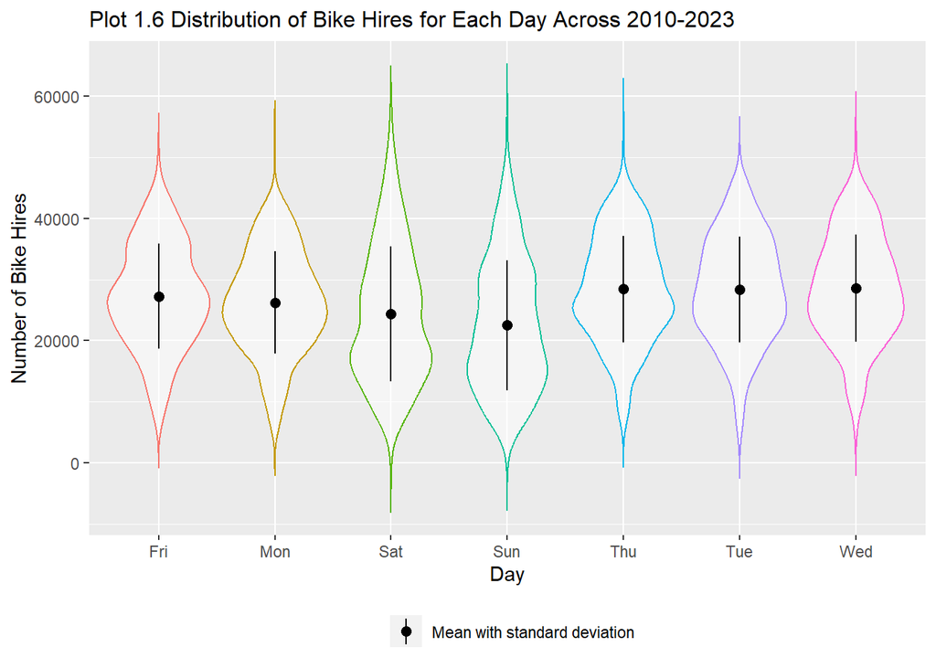

```r
# Checking the distribution of bike hires for each day across 2010-2023
ggplot(london.covid.bikes, aes(x=day, y=Hires, fill=Hires)) +
  geom_violin(trim=FALSE, alpha = 0.5, aes(color=day)) +
  stat_summary(fun.data=mean_sdl, fun.args = list(mult=1), color="black", aes(shape="Mean with standard deviation")) +
  labs(x="Day", y="Number of Bike Hires", title = "Plot 1.6 Distribution of Bike Hires for Each Day Across 2010-2023") +
  guides(col="none") +
  theme(legend.position="bottom", legend.title=element_blank(), plot.title = element_text(size = 12))
```

Plot 1.6 shows us that Saturday and Sunday have the lowest number of bike hires. This could be an indication that people rent bike more on weekday to go to work and they stay at home during weekend.

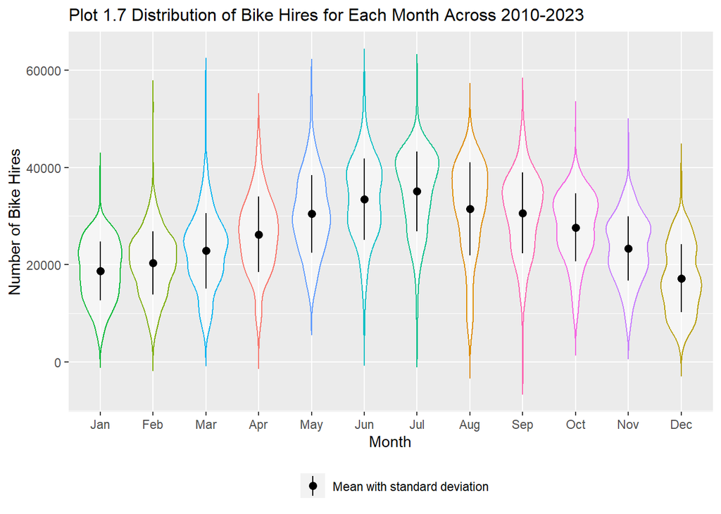

```r
# Checking the distribution of bike hires for each month across 2010-2023
ggplot(london.covid.bikes, aes(x=month, y=Hires, fill=Hires)) +
  geom_violin(trim=FALSE, alpha = 0.5, aes(color=month)) +
  stat_summary(fun.data=mean_sdl, fun.args = list(mult=1), color="black", aes(shape="Mean with standard deviation")) +
  labs(x="Month", y="Number of Bike Hires", title = "Plot 1.7 Distribution of Bike Hires for Each Month Across 2010-2023") +
  guides(col="none") +
  theme(legend.position="bottom", legend.title=element_blank(), plot.title = element_text(size = 12)) +
  scale_x_discrete(limits = month.abb)
```

Based on Plot 1.7, we can see that bike hires decreases at the end of the year and at the beginning of the year. Bike hires reaches its peak on month June-July (mid-year). It might be because end of year and beginning of year are winter season in the UK, so less number of people are using bike when they go outside.

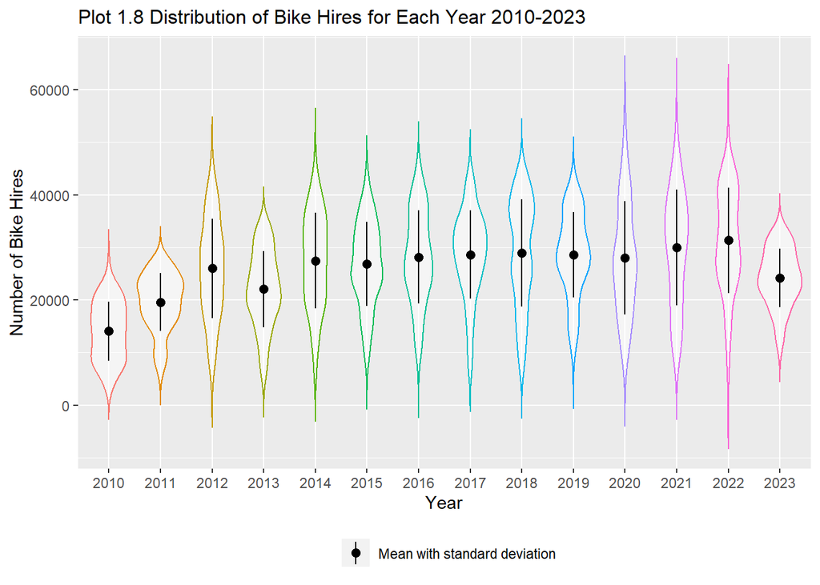

```r
# Checking the distribution of bike hires for each year 2010-2023
ggplot(london.covid.bikes, aes(x=year, y=Hires, fill=Hires)) +
  geom_violin(trim=FALSE, alpha = 0.5, aes(color=year)) +
  stat_summary(fun.data=mean_sdl, fun.args = list(mult=1), color="black", aes(shape="Mean with standard deviation")) +
  labs(x="Year", y="Number of Bike Hires", title = "Plot 1.8 Distribution of Bike Hires for Each Year 2010-2023") +
  guides(col="none") +
  theme(legend.position="bottom", legend.title=element_blank(), plot.title = element_text(size = 12))
```

### Regression Model with Time Variables

```r
# Multiple linear regression for bike hires with 3 predictors: Work From Home, Rule of 6 Indoors, and the Eat Out to Help Out scheme by including interaction with time variables (day, month, and year)
m.hires.by.wfh.rule_of_6_indoors.eat_out_to_help_out.time <- lm(Hires~wfh * rule_of_6_indoors * eat_out_to_help_out + day + month + year + wfh:day + wfh:month + wfh:year + rule_of_6_indoors:day + rule_of_6_indoors:month + rule_of_6_indoors:year + eat_out_to_help_out:day + eat_out_to_help_out:month + eat_out_to_help_out:year, data=london.covid.bikes)
summary(m.hires.by.wfh.rule_of_6_indoors.eat_out_to_help_out.time)
```

```
##
## Call:
## lm(formula = Hires ~ wfh * rule_of_6_indoors * eat_out_to_help_out +
##     day + month + year + wfh:day + wfh:month + wfh:year + rule_of_6_indoors:day +
##     rule_of_6_indoors:month + rule_of_6_indoors:year + eat_out_to_help_out:day +
##     eat_out_to_help_out:month + eat_out_to_help_out:year, data = london.covid.bikes)
##
## Residuals:
##    Min     1Q Median     3Q    Max
## -33218  -3264    525   3646  29910
##
## Coefficients: (59 not defined because of singularities)
##                                              Estimate Std. Error t value Pr(>|t|)
## (Intercept)                                  14538.53     670.28  21.690  < 2e-16 ***
## wfh1                                         -8015.13    1073.98  -7.463 1.00e-13 ***
## rule_of_6_indoors1                            4465.27    2748.75   1.624 0.104341
## eat_out_to_help_out1                         -2290.45    3097.99  -0.739 0.459742
## dayMon                                        -848.51     369.78  -2.295 0.021798 *
## daySat                                       -4321.50     369.72 -11.688  < 2e-16 ***
## daySun                                       -5820.20     369.72 -15.742  < 2e-16 ***
## dayThu                                        1211.61     370.43   3.271 0.001080 **
## dayTue                                        1194.59     370.08   3.228 0.001255 **
## dayWed                                        1396.13     370.07   3.773 0.000164 ***
## monthAug                                      5335.90     493.28  10.817  < 2e-16 ***
## monthDec                                     -7907.51     498.38 -15.866  < 2e-16 ***
## monthFeb                                     -6666.43     515.13 -12.941  < 2e-16 ***
## monthJan                                     -7747.40     504.04 -15.371  < 2e-16 ***
## monthJul                                      8495.04     507.04  16.754  < 2e-16 ***
## monthJun                                      6053.04     516.74  11.714  < 2e-16 ***
## monthMar                                     -3903.08     506.91  -7.700 1.65e-14 ***
## monthMay                                      3704.77     512.56   7.228 5.69e-13 ***
## monthNov                                     -2485.13     497.47  -4.995 6.08e-07 ***
## monthOct                                      2164.27     493.92   4.382 1.20e-05 ***
## monthSep                                      5188.83     493.63  10.512  < 2e-16 ***
## year2011                                      5845.29     587.73   9.945  < 2e-16 ***
## year2012                                     12308.31     587.55  20.948  < 2e-16 ***
## year2013                                      8304.18     587.73  14.129  < 2e-16 ***
## year2014                                     13724.01     587.73  23.351  < 2e-16 ***
## year2015                                     13128.55     588.23  22.319  < 2e-16 ***
## year2016                                     14444.94     587.55  24.585  < 2e-16 ***
```

[output cut: 92 more lines]

```
## eat_out_to_help_out1:year2016                      NA         NA      NA       NA
## eat_out_to_help_out1:year2017                      NA         NA      NA       NA
## eat_out_to_help_out1:year2018                      NA         NA      NA       NA
## eat_out_to_help_out1:year2019                      NA         NA      NA       NA
## eat_out_to_help_out1:year2020                      NA         NA      NA       NA
## eat_out_to_help_out1:year2021                      NA         NA      NA       NA
## eat_out_to_help_out1:year2022                      NA         NA      NA       NA
## eat_out_to_help_out1:year2023                      NA         NA      NA       NA
## wfh1:rule_of_6_indoors1:eat_out_to_help_out1       NA         NA      NA       NA
## ---
## Signif. codes:  0 '***' 0.001 '**' 0.01 '*' 0.05 '.' 0.1 ' ' 1
##
## Residual standard error: 6004 on 4733 degrees of freedom
## Multiple R-squared:  0.6103, Adjusted R-squared:  0.6047
## F-statistic:   109 on 68 and 4733 DF,  p-value: < 2.2e-16
```

```r
cbind(coef(m.hires.by.wfh.rule_of_6_indoors.eat_out_to_help_out.time), confint(m.hires.by.wfh.rule_of_6_indoors.eat_out_to_help_out.time))
```

```
##                                                                2.5 %     97.5 %
## (Intercept)                                  14538.53087  13224.4630 15852.5987
## wfh1                                         -8015.13320 -10120.6243 -5909.6421
## rule_of_6_indoors1                            4465.27450   -923.5489  9854.0979
## eat_out_to_help_out1                         -2290.44734  -8363.9588  3783.0641
## dayMon                                        -848.50718  -1573.4469  -123.5675
## daySat                                       -4321.50026  -5046.3311 -3596.6694
## daySun                                       -5820.19615  -6545.0254 -5095.3669
## dayThu                                        1211.60749    485.3983  1937.8167
## dayTue                                        1194.59475    469.0717  1920.1178
## dayWed                                        1396.13104    670.6177  2121.6444
## monthAug                                      5335.90212   4368.8362  6302.9680
## monthDec                                     -7907.50523  -8884.5630 -6930.4474
## monthFeb                                     -6666.42870  -7676.3256 -5656.5318
## monthJan                                     -7747.39940  -8735.5581 -6759.2407
## monthJul                                      8495.04121   7501.0120  9489.0704
## monthJun                                      6053.04245   5039.9918  7066.0931
## monthMar                                     -3903.08130  -4896.8700 -2909.2926
## monthMay                                      3704.77295   2699.9094  4709.6365
## monthNov                                     -2485.12730  -3460.4090 -1509.8456
## monthOct                                      2164.26606   1195.9610  3132.5711
## monthSep                                      5188.83487   4221.0939  6156.5758
## year2011                                      5845.29206   4693.0623  6997.5218
## year2012                                     12308.30793  11156.4307 13460.1852
## year2013                                      8304.17947   7151.9504  9456.4085
## year2014                                     13724.00540  12571.7763 14876.2345
## year2015                                     13128.54742  11975.3527 14281.7422
## year2016                                     14444.93852  13293.0656 15596.8115
## year2017                                     14900.34328  13748.1136 16052.5730
## year2018                                     15219.58797  14067.3585 16371.8174
## year2019                                     14823.34659  13671.1175 15975.5757
## year2020                                     16646.76434  15036.2443 18257.2844
## year2021                                     19400.01581  18041.6233 20758.4084
## year2022                                     25433.32123  23613.8876 27252.7549
## year2023                                     16393.14989  14541.3725 18244.9273
## wfh1:rule_of_6_indoors1                      -2018.60799  -8215.8064  4178.5904
## wfh1:eat_out_to_help_out1                             NA          NA         NA
## rule_of_6_indoors1:eat_out_to_help_out1               NA          NA         NA
## wfh1:dayMon                                  -1105.32873  -2668.9823   458.3248
## wfh1:daySat                                   5415.89724   3847.6670  6984.1274
```

[output cut: 74 more lines]

```
## eat_out_to_help_out1:monthSep                         NA          NA         NA
## eat_out_to_help_out1:year2011                         NA          NA         NA
## eat_out_to_help_out1:year2012                         NA          NA         NA
## eat_out_to_help_out1:year2013                         NA          NA         NA
## eat_out_to_help_out1:year2014                         NA          NA         NA
## eat_out_to_help_out1:year2015                         NA          NA         NA
## eat_out_to_help_out1:year2016                         NA          NA         NA
## eat_out_to_help_out1:year2017                         NA          NA         NA
## eat_out_to_help_out1:year2018                         NA          NA         NA
## eat_out_to_help_out1:year2019                         NA          NA         NA
## eat_out_to_help_out1:year2020                         NA          NA         NA
## eat_out_to_help_out1:year2021                         NA          NA         NA
## eat_out_to_help_out1:year2022                         NA          NA         NA
## eat_out_to_help_out1:year2023                         NA          NA         NA
## wfh1:rule_of_6_indoors1:eat_out_to_help_out1          NA          NA         NA
```

The model above helps us to understand more about the effect of 3 COVID-19 policies (Work From Home, Rule of 6 Indoors, and the Eat Out to Help Out scheme) to the number of bike hires by including the interaction with time variables to each scheme (day, month, year).

```r
# Model comparison between multiple linear regression with time variables and and without without time variables
anova(m.hires.by.wfh.rule_of_6_indoors.eat_out_to_help_out.intr, m.hires.by.wfh.rule_of_6_indoors.eat_out_to_help_out.time)
```

```
## Analysis of Variance Table
##
## Model 1: Hires ~ wfh * rule_of_6_indoors * eat_out_to_help_out
## Model 2: Hires ~ wfh * rule_of_6_indoors * eat_out_to_help_out + day +
##     month + year + wfh:day + wfh:month + wfh:year + rule_of_6_indoors:day +
##     rule_of_6_indoors:month + rule_of_6_indoors:year + eat_out_to_help_out:day +
##     eat_out_to_help_out:month + eat_out_to_help_out:year
##   Res.Df        RSS Df  Sum of Sq      F    Pr(>F)
## 1   4797 4.2547e+11
## 2   4733 1.7061e+11 64 2.5487e+11 110.48 < 2.2e-16 ***
## ---
## Signif. codes:  0 '***' 0.001 '**' 0.01 '*' 0.05 '.' 0.1 ' ' 1
```

Using ANOVA test, we compare the regression model before and after we combine time variables (day, month, year) as additional predictors. The result shows that the model is significantly improved by adding and interacting 3 schemes with time variables (F(64,4733) = 110.48, p<0.001). Therefore, increasing the complexity of the model by including interaction terms with day, month and year, improves the model’s ability to explain variation in bike hires.

```r
# Filter rows without NA in the summary of emmeans
filtered.summary.emmeans <- emm.model.time[complete.cases(summary(emm.model.time)), ]
print(filtered.summary.emmeans)
```

```
##  wfh rule_of_6_indoors eat_out_to_help_out day month year emmean   SE   df lower.CL upper.CL
##  0   0                 0                   Fri Apr   2010  14539  670 4733    13224    15853
##  0   0                 0                   Mon Apr   2010  13690  670 4733    12376    15004
##  0   0                 0                   Sat Apr   2010  10217  671 4733     8902    11532
##  0   0                 0                   Sun Apr   2010   8718  671 4733     7404    10033
##  0   0                 0                   Thu Apr   2010  15750  672 4733    14434    17067
##  0   0                 0                   Tue Apr   2010  15733  671 4733    14418    17048
##  0   0                 0                   Wed Apr   2010  15935  671 4733    14619    17250
##  0   0                 0                   Fri Aug   2010  19874  612 4733    18675    21074
##  0   0                 0                   Mon Aug   2010  19026  612 4733    17825    20226
##  0   0                 0                   Sat Aug   2010  15553  613 4733    14352    16754
##  0   0                 0                   Sun Aug   2010  14054  613 4733    12853    15255
##  0   0                 0                   Thu Aug   2010  21086  613 4733    19884    22288
##  0   0                 0                   Tue Aug   2010  21069  613 4733    19868    22270
##  0   0                 0                   Wed Aug   2010  21271  613 4733    20069    22472
```

[output cut: 1409 more lines]

```r
# Filter rows without NA in the means and confidence intervals
filtered.means.ci <- emm.model.time.means.ci[complete.cases(emm.model.time.means.ci), ]
print(filtered.summary.emmeans)
```

```
##  wfh rule_of_6_indoors eat_out_to_help_out day month year emmean   SE   df lower.CL upper.CL
##  0   0                 0                   Fri Apr   2010  14539  670 4733    13224    15853
##  0   0                 0                   Mon Apr   2010  13690  670 4733    12376    15004
##  0   0                 0                   Sat Apr   2010  10217  671 4733     8902    11532
##  0   0                 0                   Sun Apr   2010   8718  671 4733     7404    10033
##  0   0                 0                   Thu Apr   2010  15750  672 4733    14434    17067
##  0   0                 0                   Tue Apr   2010  15733  671 4733    14418    17048
##  0   0                 0                   Wed Apr   2010  15935  671 4733    14619    17250
##  0   0                 0                   Fri Aug   2010  19874  612 4733    18675    21074
##  0   0                 0                   Mon Aug   2010  19026  612 4733    17825    20226
##  0   0                 0                   Sat Aug   2010  15553  613 4733    14352    16754
##  0   0                 0                   Sun Aug   2010  14054  613 4733    12853    15255
##  0   0                 0                   Thu Aug   2010  21086  613 4733    19884    22288
##  0   0                 0                   Tue Aug   2010  21069  613 4733    19868    22270
##  0   0                 0                   Wed Aug   2010  21271  613 4733    20069    22472
```

[output cut: 1409 more lines]

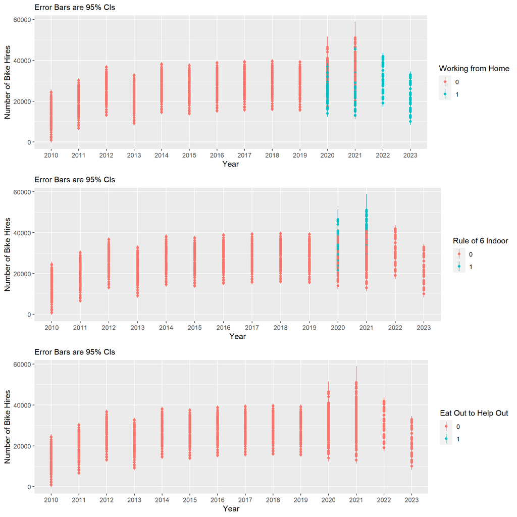

```r
ggplot.wfh.emm <- ggplot(summary(emm.model.time), aes(x=year, y=emmean, ymin=lower.CL, ymax=upper.CL, col=wfh)) + geom_point() + geom_linerange(alpha=5) + labs(x="Year", y="Number of Bike Hires", col="Working from Home", subtitle="Error Bars are 95% CIs")

ggplot.rule_of_6_indoors.emm <- ggplot(summary(emm.model.time), aes(x=year, y=emmean, ymin=lower.CL, ymax=upper.CL, col=rule_of_6_indoors)) + geom_point() + geom_linerange(alpha=5) + labs(x="Year", y="Number of Bike Hires", col="Rule of 6 Indoor", subtitle="Error Bars are 95% CIs")

ggplot.eat_out_to_help_out.emm <- ggplot(summary(emm.model.time), aes(x=year, y=emmean, ymin=lower.CL, ymax=upper.CL, col=eat_out_to_help_out)) + geom_point() + geom_linerange(alpha=5) + labs(x="Year", y="Number of Bike Hires", col="Eat Out to Help Out", subtitle="Error Bars are 95% CIs")

ggarrange(ggplot.wfh.emm, ggplot.rule_of_6_indoors.emm, ggplot.eat_out_to_help_out.emm, ncol = 1, nrow = 3)
```

Here, we try to see the estimated marginal means (emmeans) and corresponding confidence intervals fpr the combination of wfh, rule_of_6_indoors, and eat_out_to_help_out1 and their interaction with time (day, month, year). The blue coloured-dots across the year indicate changes in bike hires’ mean due to the three COVID-19 policy’s interactions with time. It is shown that number of bike hires is lower when wfh policy is applied (blue colour) compared to when wfh policy is not applied (red colour). When rule of 6 indoors is applied, the number of bike hires seems to be increasing but as it is not significant as per the regression model result. Eat out help out seems have no effect to the mean of bike hires, which is synchronize with the regression model’s result.

### Conclusion For Question 1

The regression model provides insights into the effects of COVID-19 policies on bike hires, considering interactions with time variables. In the first analysis, we only make interaction of 3 schemes in the regression model (Work From Home, Rule of 6 Indoors, and the Eat Out to Help Out) and the result is that all 3 schemes have positive impact to the bike hires, meaning when those schemes are implemented by the UK government during COVID-19, number of bike hires seems to increase. However, when we try to control for the effect of potential differences between different years, months, and days, the result is different. In the second analysis, the model tells us that Work From Home has a significant negative impact during weekdays but a positive impact on weekends. It means wfh policy makes the number of bike hires decreases during weekday since people are working from home, while it boosts the number of bike hires during weekend since people mostly are having the day off and go outside for recreation after 5 days stay at home to work. Rule of 6 Indoors and Eat Out to Help Out show limited or no significant effects on bike hires overall.

Another thing to highlight is that Work From Home, Rule of 6 Indoors, and the Eat Out to Help Out are policies that were issued by government to overcome and prevent the effect of COVID-19. The dataset provided was collected from 2010, which means those policies were not present pre-COVID-19. Thus, there will be some bias when examining the effect of these elements upon the number of bike rentals.

# Question 2

### Data Dictionary

| Variable | Description |
| --- | --- |
| sold.by | The name of the publishers |
| publisher.type | The type of the publishers |
| genre | The genre of the books |
| avg.review | The average of review scores of the books |
| daily.sales | The average number of book daily sales |
| total.reviews | The total number of reviews given to each book |
| sale.price | The price of the book |

### Data Preparation

```r
# Read the data
publisher.sales <- read_csv('publisher_sales.csv')
```

We read the dataset of book sales.

```r
# Us summary to check if there is anomaly in the data and see the distribution of values
summary(publisher.sales)
```

```
##    sold by          publisher.type        genre             avg.review     daily.sales
##  Length:6000        Length:6000        Length:6000        Min.   :0.000   Min.   : -0.53
##  Class :character   Class :character   Class :character   1st Qu.:4.090   1st Qu.: 64.22
##  Mode  :character   Mode  :character   Mode  :character   Median :4.410   Median : 81.59
##                                                           Mean   :4.269   Mean   : 86.37
##                                                           3rd Qu.:4.610   3rd Qu.:104.73
##                                                           Max.   :4.980   Max.   :209.34
##  total.reviews     sale.price
##  Min.   :  0.0   Min.   : 1.17
##  1st Qu.:104.0   1st Qu.: 7.34
##  Median :128.0   Median : 9.31
##  Mean   :132.7   Mean   :10.30
##  3rd Qu.:163.0   3rd Qu.:13.58
##  Max.   :243.0   Max.   :22.00
```

```r
str(publisher.sales)
```

```
## spc_tbl_ [6,000 × 7] (S3: spec_tbl_df/tbl_df/tbl/data.frame)
##  $ sold by       : chr [1:6000] "Amazon Digital Services,  Inc." "HarperCollins Publishers" "Amazon Digital Services,  Inc." "Amazon Digital Services,  Inc." ...
##  $ publisher.type: chr [1:6000] "indie" "big five" "small/medium" "small/medium" ...
##  $ genre         : chr [1:6000] "adult_fiction" "YA_fiction" "adult_fiction" "YA_fiction" ...
##  $ avg.review    : num [1:6000] 4.5 4.64 2.5 4.5 4.98 3.98 4.62 3.5 4.64 4.56 ...
##  $ daily.sales   : num [1:6000] 84.4 113.1 70.8 149.4 135.7 ...
##  $ total.reviews : num [1:6000] 151 184 125 225 194 123 130 110 129 119 ...
##  $ sale.price    : num [1:6000] 5.12 6.91 6.27 4.91 7.39 ...
##  - attr(*, "spec")=
##   .. cols(
##   ..   `sold by` = col_character(),
##   ..   publisher.type = col_character(),
##   ..   genre = col_character(),
##   ..   avg.review = col_double(),
##   ..   daily.sales = col_double(),
##   ..   total.reviews = col_double(),
##   ..   sale.price = col_double()
##   .. )
##  - attr(*, "problems")=<externalptr>
```

We check the type of data using str function and try to find if there is any missing value (NA) in the data using summary function. Based on the summary, no missing value has been found.

```r
# Check the duplication in the dataset
which(duplicated(publisher.sales))
```

```
## integer(0)
```

Using function “which (duplicated)”, we try to find if there is any duplication of the data in the dataset and we found no duplication.

```r
# Set the correct measurement level of data types
col <- c('sold by', 'publisher.type', 'genre')
publisher.sales[col] <- lapply(publisher.sales[col], as.factor)
```

We change the data type of “sold by”, “publisher.type”, and “genre” to factor so it can be used properly for ggplot.

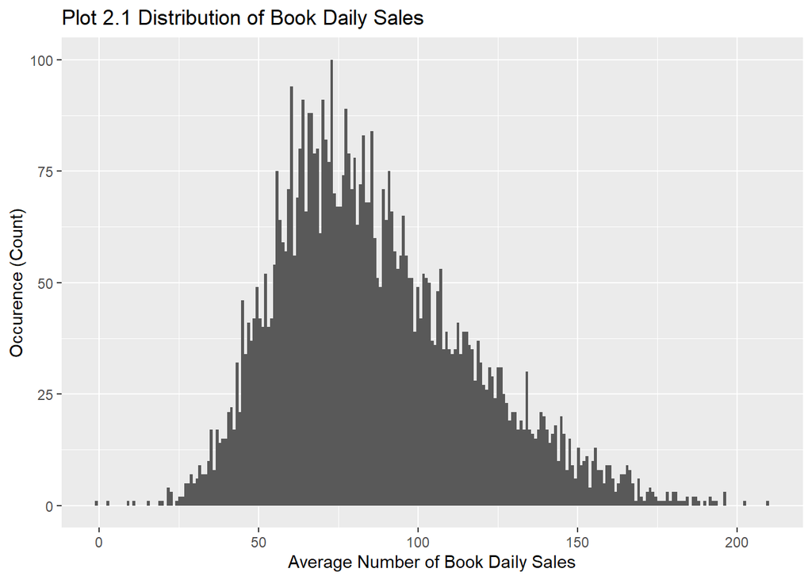

```r
# Using histogram to check the distribution of daily.sales is normal or not
ggplot(publisher.sales) + geom_histogram(aes(daily.sales), binwidth=0.9) + labs(title='Plot 2.1 Distribution of Book Daily Sales', x='Average Number of Book Daily Sales', y='Occurence (Count)')
```

Data daily.sales (average number of book daily sales) seems (roughly) normally distributed.

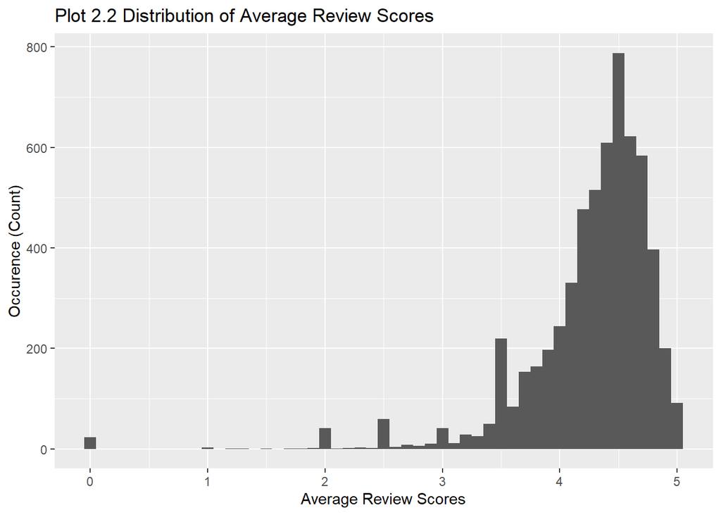

```r
# Using histogram to check the distribution of avg.review is normal or not
ggplot(publisher.sales) + geom_histogram(aes(avg.review), binwidth=0.1) + labs(title='Plot 2.2 Distribution of Average Review Scores', x='Average Review Scores', y='Occurence (Count)')
```

Data avg.review (average review scores) seems a little bit negative skew but it is still acceptable to be used on linear regression model.

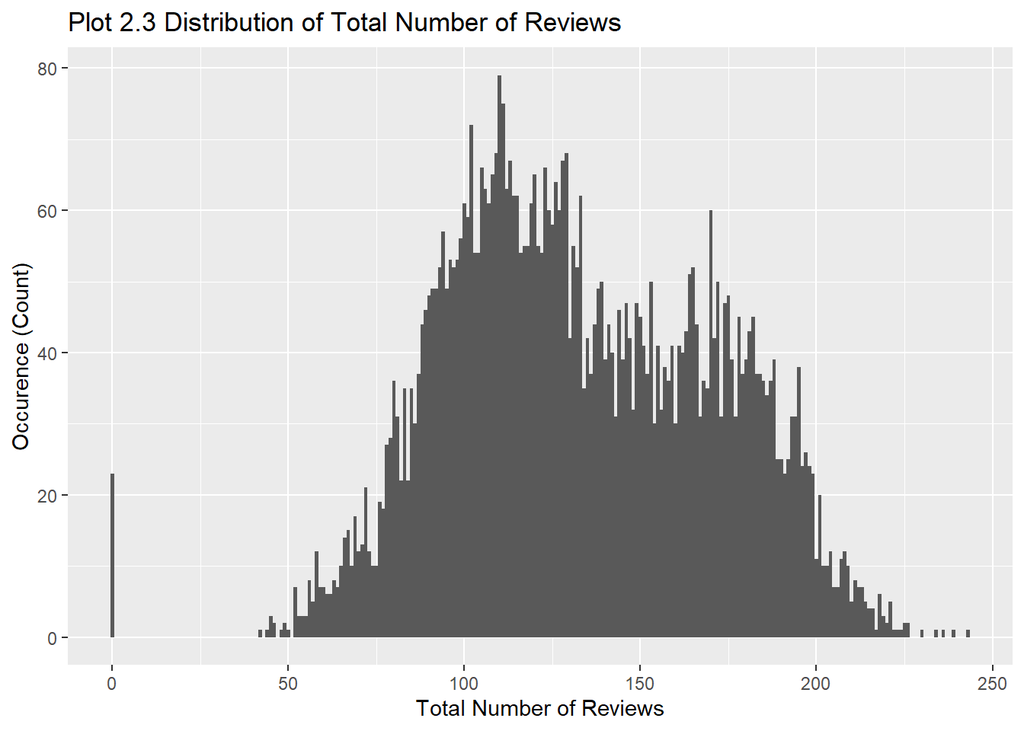

```r
# Using histogram to check the distribution of total.reviews is normal or not
ggplot(publisher.sales) + geom_histogram(aes(total.reviews), binwidth=1) + labs(title='Plot 2.3 Distribution of Total Number of Reviews', x='Total Number of Reviews', y='Occurence (Count)')
```

Data total.reviews (total number of reviews) seems to be slightly bimodal distributed.

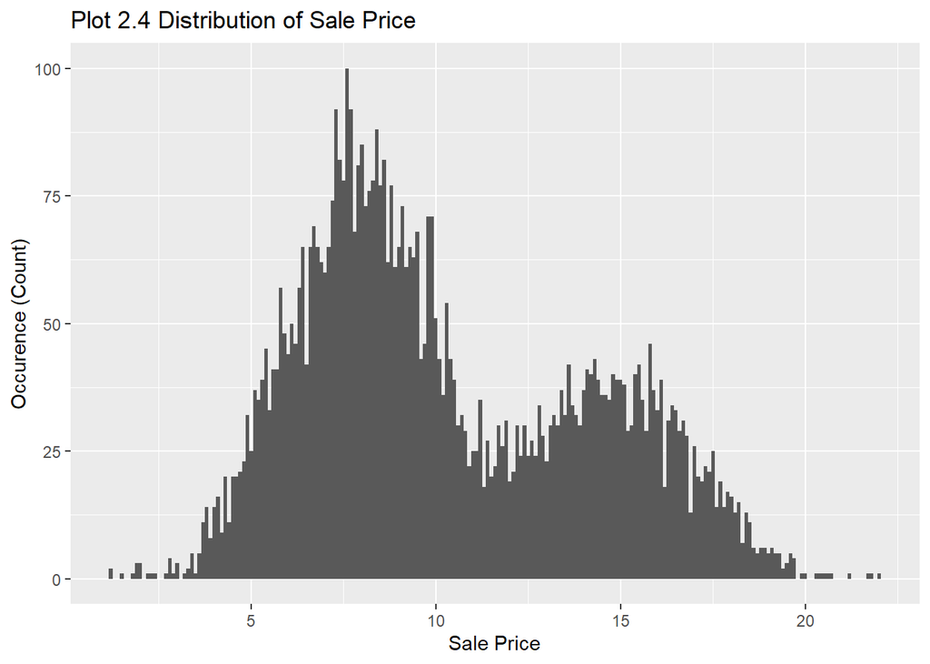

```r
# Using histogram to check the distribution of total.reviews is normal or not
ggplot(publisher.sales) + geom_histogram(aes(sale.price), binwidth=0.1) + labs(title='Plot 2.4 Distribution of Sale Price', x='Sale Price', y='Occurence (Count)')
```

Data sale.price (sale price) seems to have bimodal distribution.

There are small number of data that seems to be outliers but since those values are not extreme, we can keep them and used for analysis.

### Data Analysis Using Plot

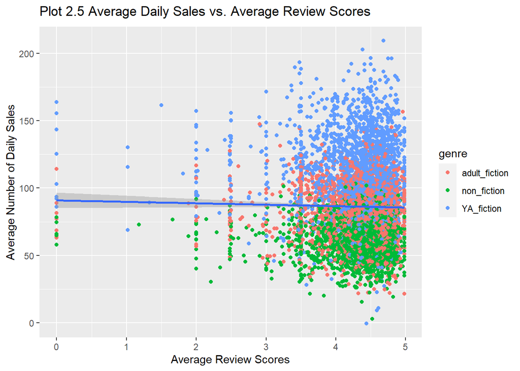

```r
# Plotting the data of avg.review vs. daily.sales
ggplot(publisher.sales, aes(x=avg.review, y=daily.sales)) + geom_point(aes(colour=genre)) + labs(x="Average Review Scores", y="Average Number of Daily Sales", title=expression('Plot 2.5 Average Daily Sales vs. Average Review Scores')) + geom_smooth(method=lm)
```

Plot 2.5 displays that average review scores has a slightly negative correlation with the average number of daily sales. The higher the average review scores of the book, the lower the average number of book daily sales.

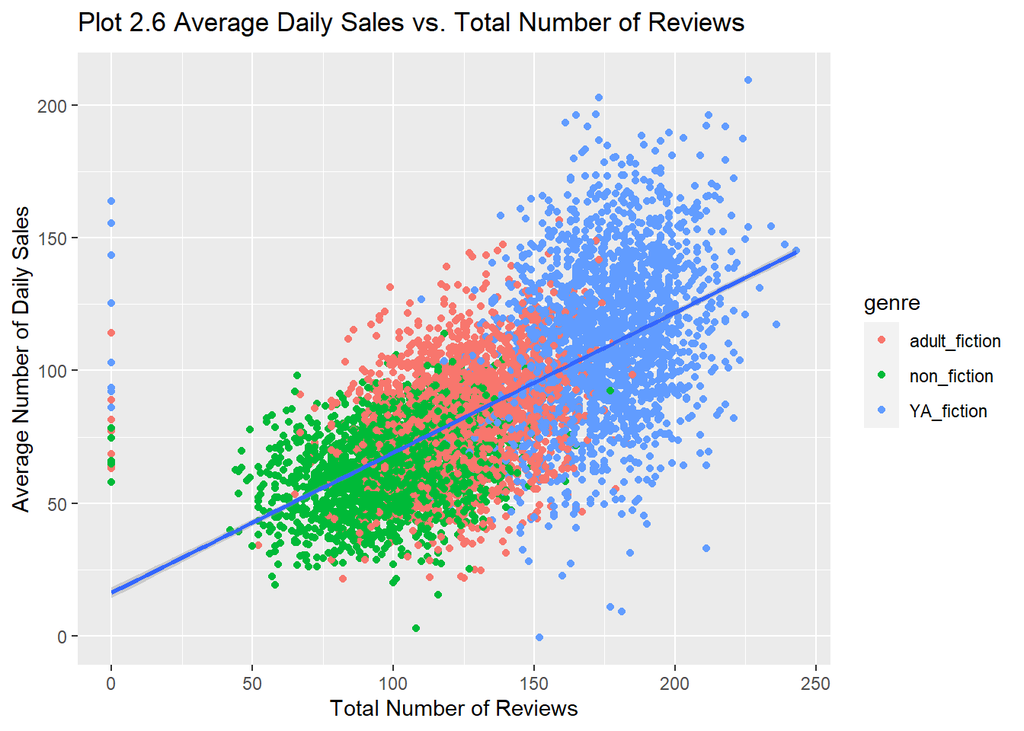

```r
# Plotting the data of total.reviews vs. daily.sales
ggplot(publisher.sales, aes(x=total.reviews, y=daily.sales)) + geom_point(aes(colour=genre)) + labs(x="Total Number of Reviews", y="Average Number of Daily Sales", title=expression('Plot 2.6 Average Daily Sales vs. Total Number of Reviews')) + geom_smooth(method=lm)
```

As we can see from the above Plot 2.6, the total number of reviews seems to have a positive correlation to the average number of daily sales. The higher the total number of review, the higher the average number of daily sales. We can also see from Plot 2.6 that YA_fiction (young adult) genre has the highest total number of reviews and non-fiction genre has the lowest total number of reviews.

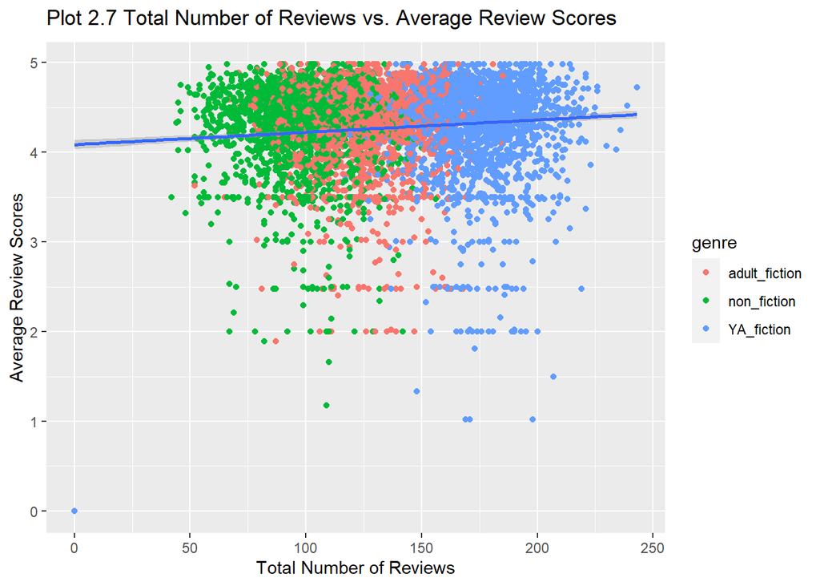

```r
# Plotting the data of total.reviews vs. avg.review
ggplot(publisher.sales, aes(x=total.reviews, y=avg.review)) + geom_point(aes(colour=genre)) + labs(x="Total Number of Reviews", y="Average Review Scores", title=expression('Plot 2.7 Total Number of Reviews vs. Average Review Scores')) + geom_smooth(method=lm)
```

### Correlation and Regression Model for Average Review Scores and Total Number of Reviews

```r
# Use Pearson correlation matrix to show the correlation between each pair of variables (correlation coefficient and p-value)
rcorr(as.matrix(select(publisher.sales, daily.sales, avg.review, total.reviews)))
```

```
##               daily.sales avg.review total.reviews
## daily.sales          1.00      -0.02          0.66
## avg.review          -0.02       1.00          0.09
## total.reviews        0.66       0.09          1.00
##
## n= 6000
##
##
## P
##               daily.sales avg.review total.reviews
## daily.sales               0.1226     0.0000
## avg.review    0.1226                 0.0000
## total.reviews 0.0000      0.0000
```

The correlation between avg.review and total.reviews is significant under NHST, which means the r-value is not zero. We can see that avg.review and total.reviews have a quite low r value = 0.09 and they have 0.81% of shared variance. This suggests that we shouldn’t have any problems with multicollinearity if we use them both as predictors in a multiple regression.

```r
# Use Spearman correlation matrix to show the correlation between each pair of variables (correlation coefficient and p-value)
rcorr(as.matrix(select(publisher.sales, daily.sales, avg.review, total.reviews)), type = "spearman")
```

```
##               daily.sales avg.review total.reviews
## daily.sales          1.00      -0.01          0.68
## avg.review          -0.01       1.00          0.02
## total.reviews        0.68       0.02          1.00
##
## n= 6000
##
##
## P
##               daily.sales avg.review total.reviews
## daily.sales               0.5597     0.0000
## avg.review    0.5597                 0.1777
## total.reviews 0.0000      0.1777
```

Since the distributions of avg.review and total.reviews appear visually to be a little bit negative skew and potentially slightly bimodal respectively, we try to compare the result of Pearson and Spearman correlation. If we use Spearman correlation matrix, the result of r value is even lower (r value = 0.02), meaning we don’t have problem with multicollinearity when avg.review and total.reviews are used together in regression model.

```r
# Simple linear regression for average number of daily sales and average review scores
m_daily.sales_by_avg.review <- lm(daily.sales~avg.review, data=publisher.sales)
summary(m_daily.sales_by_avg.review)
```

```
##
## Call:
## lm(formula = daily.sales ~ avg.review, data = publisher.sales)
##
## Residuals:
##     Min      1Q  Median      3Q     Max
## -86.721 -22.129  -4.722  18.267 123.403
##
## Coefficients:
##             Estimate Std. Error t value Pr(>|t|)
## (Intercept)  90.8944     2.9543  30.767   <2e-16 ***
## avg.review   -1.0593     0.6859  -1.544    0.123
## ---
## Signif. codes:  0 '***' 0.001 '**' 0.01 '*' 0.05 '.' 0.1 ' ' 1
##
## Residual standard error: 30.22 on 5998 degrees of freedom
## Multiple R-squared:  0.0003974,  Adjusted R-squared:  0.0002308
## F-statistic: 2.385 on 1 and 5998 DF,  p-value: 0.1226
```

```r
cbind(coef(m_daily.sales_by_avg.review), confint(m_daily.sales_by_avg.review))
```

```
##                           2.5 %     97.5 %
## (Intercept) 90.894430 85.102983 96.6858777
## avg.review  -1.059283 -2.403959  0.2853935
```

The simple linear regression model between average number of daily sales and average review scores shows us that for every 1 point increase in average review score, there is a drop of of average daily sales by 1 unit (t(5998) = -1.54, p = 0.12, 95% CI [-2.40, 0.29]), but it is not statistically significant since p-value > 0.005.

```r
# Simple linear regression for average number of daily sales and total number of reviews
m_daily.sales_by_total.reviews <- lm(daily.sales~total.reviews, data=publisher.sales)
summary(m_daily.sales_by_total.reviews)
```

```
##
## Call:
## lm(formula = daily.sales ~ total.reviews, data = publisher.sales)
##
## Residuals:
##      Min       1Q   Median       3Q      Max
## -102.667  -14.694   -1.125   13.458  147.319
##
## Coefficients:
##                Estimate Std. Error t value Pr(>|t|)
## (Intercept)   16.381371   1.070717   15.30   <2e-16 ***
## total.reviews  0.527490   0.007761   67.97   <2e-16 ***
## ---
## Signif. codes:  0 '***' 0.001 '**' 0.01 '*' 0.05 '.' 0.1 ' ' 1
##
## Residual standard error: 22.72 on 5998 degrees of freedom
## Multiple R-squared:  0.4351, Adjusted R-squared:  0.435
## F-statistic:  4620 on 1 and 5998 DF,  p-value: < 2.2e-16
```

```r
cbind(coef(m_daily.sales_by_total.reviews), confint(m_daily.sales_by_total.reviews))
```

```
##                              2.5 %     97.5 %
## (Intercept)   16.3813714 14.282382 18.4803612
## total.reviews  0.5274902  0.512276  0.5427044
```

```r
# Multiple linear regression without interaction for average number of sales, average review scores, and total number of reviews
m_daily.sales_by_avg.review_total.reviews <- lm(daily.sales~avg.review + total.reviews, data=publisher.sales)
summary(m_daily.sales_by_avg.review_total.reviews)
```

```
##
## Call:
## lm(formula = daily.sales ~ avg.review + total.reviews, data = publisher.sales)
##
## Residuals:
##      Min       1Q   Median       3Q      Max
## -101.573  -14.529   -0.909   13.669  129.721
##
## Coefficients:
##                Estimate Std. Error t value Pr(>|t|)
## (Intercept)   33.978718   2.357956  14.410   <2e-16 ***
## avg.review    -4.306466   0.514881  -8.364   <2e-16 ***
## total.reviews  0.533428   0.007749  68.836   <2e-16 ***
## ---
## Signif. codes:  0 '***' 0.001 '**' 0.01 '*' 0.05 '.' 0.1 ' ' 1
##
## Residual standard error: 22.59 on 5997 degrees of freedom
## Multiple R-squared:  0.4416, Adjusted R-squared:  0.4414
## F-statistic:  2371 on 2 and 5997 DF,  p-value: < 2.2e-16
```

```r
cbind(coef(m_daily.sales_by_avg.review_total.reviews), confint(m_daily.sales_by_avg.review_total.reviews))
```

```
##                               2.5 %     97.5 %
## (Intercept)   33.9787175 29.3562756 38.6011594
## avg.review    -4.3064660 -5.3158175 -3.2971145
## total.reviews  0.5334285  0.5182371  0.5486198
```

When estimating the effect of both average review scores and number of reviews in the same regression, we find that the increase of 1 point in average review score predicts 4 units drop of average daily sales (t(5997) = -8.364, p<0.001, 95% CI [-5.32, -3.29]) and an increase in total number of reviews by 1 count predicts an increase in average daily sales of 0.53 (t(5997) = 68.84, p<0.001, 95% CI [0.52, 0.55]).

```r
# Multiple linear regression with interaction for average number of sales, average review scores, and total number of reviews
m_daily.sales_by_avg.review_total.reviews_intr <- lm(daily.sales~avg.review * total.reviews, data=publisher.sales)
summary(m_daily.sales_by_avg.review_total.reviews_intr)
```

```
##
## Call:
## lm(formula = daily.sales ~ avg.review * total.reviews, data = publisher.sales)
##
## Residuals:
##      Min       1Q   Median       3Q      Max
## -104.318  -14.401   -0.873   13.622   94.395
##
## Coefficients:
##                            Estimate Std. Error t value Pr(>|t|)
## (Intercept)               76.107846   4.169256  18.255  < 2e-16 ***
## avg.review               -14.673445   0.991327 -14.802  < 2e-16 ***
## total.reviews              0.139838   0.033199   4.212 2.57e-05 ***
## avg.review:total.reviews   0.095620   0.007848  12.184  < 2e-16 ***
## ---
## Signif. codes:  0 '***' 0.001 '**' 0.01 '*' 0.05 '.' 0.1 ' ' 1
##
## Residual standard error: 22.32 on 5996 degrees of freedom
## Multiple R-squared:  0.4551, Adjusted R-squared:  0.4548
## F-statistic:  1669 on 3 and 5996 DF,  p-value: < 2.2e-16
```

```r
cbind(coef(m_daily.sales_by_avg.review_total.reviews_intr), confint(m_daily.sales_by_avg.review_total.reviews_intr))
```

```
##                                              2.5 %      97.5 %
## (Intercept)               76.10784576  67.93460422  84.2810873
## avg.review               -14.67344515 -16.61680183 -12.7300885
## total.reviews              0.13983789   0.07475610   0.2049197
## avg.review:total.reviews   0.09561996   0.08023496   0.1110050
```

Here, interaction term is included in the model and the result shows that the interaction of average review score and total number of reviews is a significant predictor for average number of daily sales (t(5996) = 12.18, p <0.001, 95% CI [0.08, 0.11]).

```r
# Check the multicollinearity for multiple linear regression (avg.review and total.reviews as predictors)
vif(m_daily.sales_by_avg.review_total.reviews)
```

```
##    avg.review total.reviews
##      1.008465      1.008465
```

We use Variance Inflation Factor scores (VIFs) to get a measure of collinearity within our regression model. Generally, VIF scores of less than 5 don’t warrant any further action. Based on the low VIF score above, avg.review and total.reviews do not cause multicollinearity and can be used as predictors in the same model.

```r
# Model comparison between multiple linear regression without interaction and with interaction (avg.review and total.reviews as predictors)
anova(m_daily.sales_by_avg.review_total.reviews, m_daily.sales_by_avg.review_total.reviews_intr)
```

```
## Analysis of Variance Table
##
## Model 1: daily.sales ~ avg.review + total.reviews
## Model 2: daily.sales ~ avg.review * total.reviews
##   Res.Df     RSS Df Sum of Sq      F    Pr(>F)
## 1   5997 3059870
## 2   5996 2985945  1     73925 148.45 < 2.2e-16 ***
## ---
## Signif. codes:  0 '***' 0.001 '**' 0.01 '*' 0.05 '.' 0.1 ' ' 1
```

The model comparison test shows that the overall model fit is significantly improved (F(1,5996) = 148.45, p <0.001). Therefore, increasing the complexity of the model by including interaction terms improves the model’s ability to explain variation in average number of daily sales.

```r
# Estimated Marginal Means (Emmeans) for interaction between avg.review and total.reviews
emm.model.daily.sales.avg.review.total.reviews <- emmeans(m_daily.sales_by_avg.review_total.reviews_intr, ~ avg.review * total.reviews)
summary(emm.model.daily.sales.avg.review.total.reviews)
```

```
##  avg.review total.reviews emmean    SE   df lower.CL upper.CL
##        4.27           133   86.2 0.289 5996     85.6     86.7
##
## Confidence level used: 0.95
```

```r
emm.model.daily.sales.avg.review.total.reviews.means.ci <- confint(emm.model.daily.sales.avg.review.total.reviews)
```

At an average review score of 4.27 with a total of 133 reviews, the estimated marginal mean is 86.2, 95% CI [85.6, 86.7]. This suggests that, based on the model and predictor variables, we are reasonably confident that the true average outcome value falls within this interval.

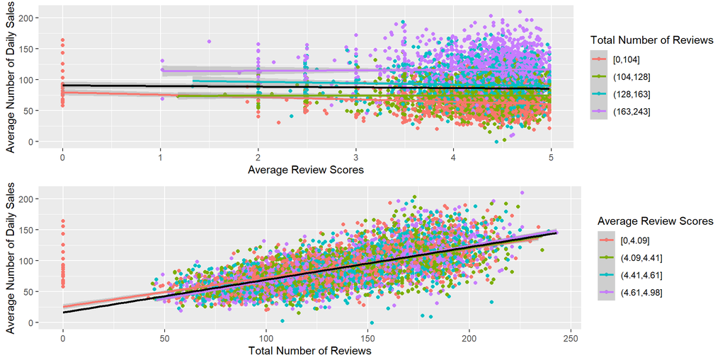

```r
# Interquartile plot to help analysing which variable is matter more: avg.review or total.reviews?
avg.review.bins <- quantile(pull(publisher.sales, avg.review))
publisher.sales <- publisher.sales %>% mutate(avg.review.bins=cut(avg.review, avg.review.bins, include.lowest=TRUE))

total.reviews.bins <- quantile(pull(publisher.sales, total.reviews))
publisher.sales <- publisher.sales %>% mutate(total.reviews.bins=cut(total.reviews, total.reviews.bins, include.lowest=TRUE))

grid.arrange(
    ggplot(publisher.sales, aes(x=avg.review, y=daily.sales, col=total.reviews.bins)) + geom_point() + geom_smooth(method=lm) + geom_smooth(mapping=aes(col=NULL), method=lm, col="black") + labs(x="Average Review Scores", y="Average Number of Daily Sales", col="Total Number of Reviews"),
    ggplot(publisher.sales, aes(x=total.reviews, y=daily.sales, col=avg.review.bins)) + geom_point() + geom_smooth(method=lm) + geom_smooth(mapping=aes(col=NULL), method=lm, col="black") + labs(x="Total Number of Reviews", y="Average Number of Daily Sales", col="Average Review Scores")
)
```

We can see from the top subplot that there is not a super obvious slope between average review scores and average number of daily sales, but the dot colours for the total number of reviews are higher up. The slopes of the lines show that there is not a very big reduction in average number of daily sales as average review scores increases, but the lines are very separated, indicating more sales for the higher total number of reviews quartiles.

In the bottom subplot, the points and slopes are defined by total number of reviews and they show a noticeably steeper increase plotted against average number of daily sales. However, the different lines are now much closer together, indicating that the higher average review scores quartiles don’t have very much higher average number of daily sales.

### Data Analysis Using Plot for Each Genre

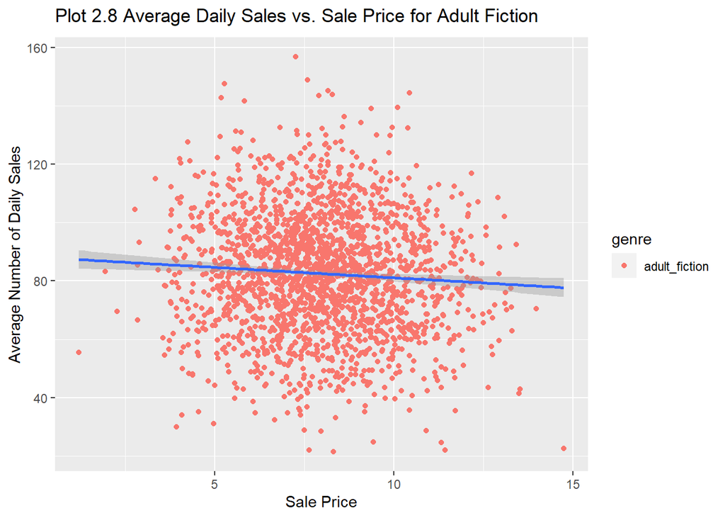

```r
# Plot for book with adult fiction genre
publisher.sales.adult.fiction <- publisher.sales[publisher.sales$genre == "adult_fiction", ]

ggplot(publisher.sales.adult.fiction, aes(x=sale.price, y=daily.sales)) + geom_point(aes(colour=genre)) + labs(x="Sale Price", y="Average Number of Daily Sales", title=expression('Plot 2.8 Average Daily Sales vs. Sale Price for Adult Fiction')) + geom_smooth(method=lm)
```

In Plot 2.8, we are shown that sales price has negative correlation with adult fiction book. When sale price increases, average number of daily sales of adult fiction book decreases.

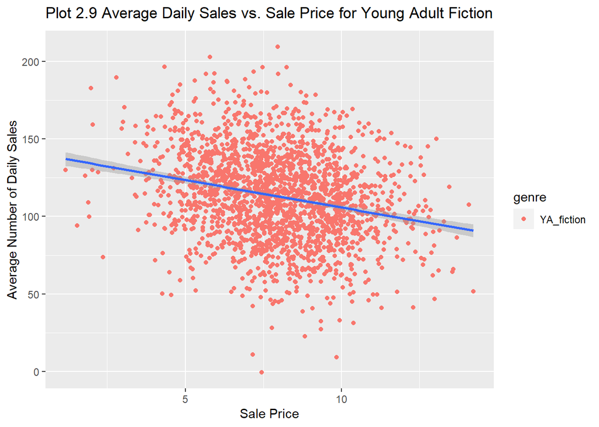

```r
# Plot for book with young adult fiction (YA fiction) genre
publisher.sales.YA.fiction <- publisher.sales[publisher.sales$genre == "YA_fiction", ]

ggplot(publisher.sales.YA.fiction, aes(x=sale.price, y=daily.sales)) + geom_point(aes(colour=genre)) + labs(x="Sale Price", y="Average Number of Daily Sales", title=expression('Plot 2.9 Average Daily Sales vs. Sale Price for Young Adult Fiction')) + geom_smooth(method=lm)
```

Plot 2.9 displays that sales price has negative correlation with young adult fiction book. When sale price increases, average number of daily sales of young adult fiction book decreases.

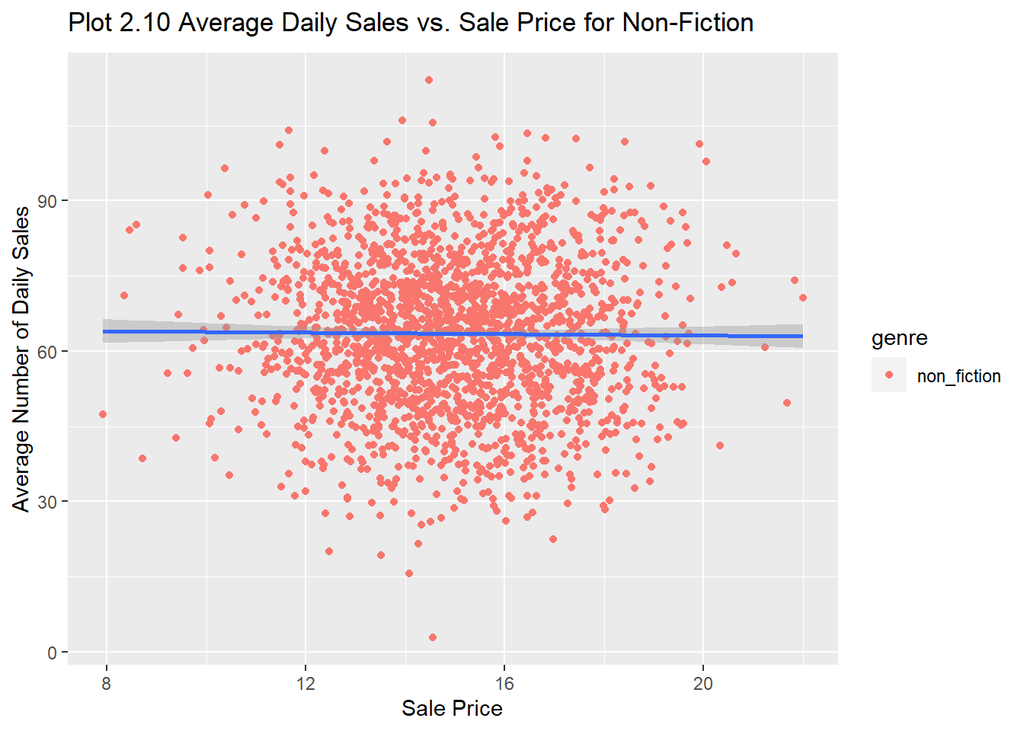

```r
# Plot for book with non-fiction genre
publisher.sales.non.fiction <- publisher.sales[publisher.sales$genre == "non_fiction", ]

ggplot(publisher.sales.non.fiction, aes(x=sale.price, y=daily.sales)) + geom_point(aes(colour=genre)) + labs(x="Sale Price", y="Average Number of Daily Sales", title=expression('Plot 2.10 Average Daily Sales vs. Sale Price for Non-Fiction')) + geom_smooth(method=lm)
```

We can see from Plot 2.10, sales price seems to have no correlation with non-fiction book, which means the increase of decrease of sales price does not impact the average number of daily sales of non-fiction book.

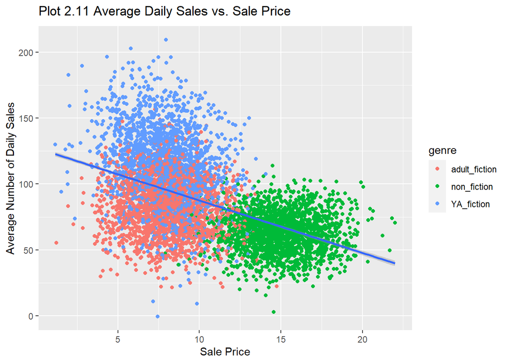

```r
# Plot for book of all genres
ggplot(publisher.sales, aes(x=sale.price, y=daily.sales)) + geom_point(aes(colour=genre)) + labs(x="Sale Price", y="Average Number of Daily Sales", title=expression('Plot 2.11 Average Daily Sales vs. Sale Price')) + geom_smooth(method=lm)
```

Plot 2.11 suggests that average daily sales of book generally negatively correlates with sale price. The more expensive the sale price, the lower the average daily sales of book. This can be an indication that less number of people will buy expensive book.

### Regression Model for Sale Price and Genre

```r
# Simple linear regression for average number of daily sales and sale price
m_daily.sales_by_sale.price <- lm(daily.sales~sale.price, data=publisher.sales)
summary(m_daily.sales_by_sale.price)
```

```
##
## Call:
## lm(formula = daily.sales ~ sale.price, data = publisher.sales)
##
## Residuals:
##     Min      1Q  Median      3Q     Max
## -98.224 -17.382  -1.922  15.227 113.674
##
## Coefficients:
##              Estimate Std. Error t value Pr(>|t|)
## (Intercept) 127.31696    0.95722  133.01   <2e-16 ***
## sale.price   -3.97625    0.08704  -45.68   <2e-16 ***
## ---
## Signif. codes:  0 '***' 0.001 '**' 0.01 '*' 0.05 '.' 0.1 ' ' 1
##
## Residual standard error: 26.03 on 5998 degrees of freedom
## Multiple R-squared:  0.2581, Adjusted R-squared:  0.258
## F-statistic:  2087 on 1 and 5998 DF,  p-value: < 2.2e-16
```

```r
cbind(coef(m_daily.sales_by_sale.price), confint(m_daily.sales_by_sale.price))
```

```
##                             2.5 %    97.5 %
## (Intercept) 127.316964 125.440463 129.19346
## sale.price   -3.976249  -4.146878  -3.80562
```

```r
# Multiple linear regression for average number of daily sales, sale price, and genre without interaction
m_daily.sales_by_sale.price_genre <- lm(daily.sales~sale.price + genre, data=publisher.sales)
summary(m_daily.sales_by_sale.price_genre)
```

```
##
## Call:
## lm(formula = daily.sales ~ sale.price + genre, data = publisher.sales)
##
## Residuals:
##      Min       1Q   Median       3Q      Max
## -114.304  -13.736    0.289   13.548   96.295
##
## Coefficients:
##                  Estimate Std. Error t value Pr(>|t|)
## (Intercept)       93.9570     1.2437  75.546  < 2e-16 ***
## sale.price        -1.4311     0.1432  -9.996  < 2e-16 ***
## genrenon_fiction  -9.0252     1.2223  -7.384 1.75e-13 ***
## genreYA_fiction   30.4787     0.6992  43.594  < 2e-16 ***
## ---
## Signif. codes:  0 '***' 0.001 '**' 0.01 '*' 0.05 '.' 0.1 ' ' 1
##
## Residual standard error: 22.11 on 5996 degrees of freedom
## Multiple R-squared:  0.4651, Adjusted R-squared:  0.4649
## F-statistic:  1738 on 3 and 5996 DF,  p-value: < 2.2e-16
```

```r
cbind(coef(m_daily.sales_by_sale.price_genre), confint(m_daily.sales_by_sale.price_genre))
```

```
##                                 2.5 %    97.5 %
## (Intercept)      93.957015  91.518911 96.395120
## sale.price       -1.431052  -1.711714 -1.150389
## genrenon_fiction -9.025219 -11.421365 -6.629073
## genreYA_fiction  30.478661  29.108075 31.849247
```

When we include genre as a predictor in the regression model, we can interpret the model as below.

1. For 1 GBP increase in sale price, daily sales are estimated to decrease by approximately 1.43 units (t(5996) = -9.99, p<0.001, CI [-1.71, -1.15]).
2. Compared to the reference genre (adult fiction), the genre non-fiction is associated with a decrease of approximately 9.03 units in average number of daily sales (t(5996) = -7.38, p<0.001, CI [-11.42, -6.63]).
3. Compared to the reference genre (adult fiction), the genre young adult fiction is associated with an increase of approximately 30.48 units in average number of daily sales (t(5996) = 43.59, p<0.001, CI [29.11, 31.85]). The model suggests that both sale price and genre are significant predictors of daily sales. Higher sale price is correlated with lower average number of daily sales, and different genres have different effects on daily sales compared to the reference genre (adult fiction). The adjusted R-squared suggests that the model is a good fit for the data (0.46).

```r
# Multiple linear regression for average number of daily sales, sale price, and genre with interaction
m_daily.sales_by_sale.price_genre_intr <- lm(daily.sales~sale.price * genre, data=publisher.sales)
summary(m_daily.sales_by_sale.price_genre_intr)
```

```
##
## Call:
## lm(formula = daily.sales ~ sale.price * genre, data = publisher.sales)
##
## Residuals:
##     Min      1Q  Median      3Q     Max
## -115.35  -13.69    0.19   13.54   96.32
##
## Coefficients:
##                             Estimate Std. Error t value Pr(>|t|)
## (Intercept)                  88.2127     2.0456  43.123  < 2e-16 ***
## sale.price                   -0.7104     0.2492  -2.851  0.00437 **
## genrenon_fiction            -23.6300     4.1904  -5.639 1.79e-08 ***
## genreYA_fiction              52.9727     2.8720  18.444  < 2e-16 ***
## sale.price:genrenon_fiction   0.6383     0.3474   1.838  0.06617 .
## sale.price:genreYA_fiction   -2.8284     0.3502  -8.077 7.99e-16 ***
## ---
## Signif. codes:  0 '***' 0.001 '**' 0.01 '*' 0.05 '.' 0.1 ' ' 1
##
## Residual standard error: 21.91 on 5994 degrees of freedom
## Multiple R-squared:  0.4751, Adjusted R-squared:  0.4746
## F-statistic:  1085 on 5 and 5994 DF,  p-value: < 2.2e-16
```

```r
cbind(coef(m_daily.sales_by_sale.price_genre_intr), confint(m_daily.sales_by_sale.price_genre_intr))
```

```
##                                                2.5 %      97.5 %
## (Intercept)                  88.2127260  84.20262631  92.2228258
## sale.price                   -0.7104194  -1.19885748  -0.2219813
## genrenon_fiction            -23.6300182 -31.84479066 -15.4152457
## genreYA_fiction              52.9726981  47.34245309  58.6029431
## sale.price:genrenon_fiction   0.6383178  -0.04263807   1.3192738
## sale.price:genreYA_fiction   -2.8283765  -3.51488477  -2.1418681
```

By making sale price and genre as interaction, we we can interpret the model as below.

```r
# Model comparison between multiple linear regression without interaction and with interaction (sale.price and genre as predictors)
anova(m_daily.sales_by_sale.price_genre, m_daily.sales_by_sale.price_genre_intr)
```

```
## Analysis of Variance Table
##
## Model 1: daily.sales ~ sale.price + genre
## Model 2: daily.sales ~ sale.price * genre
##   Res.Df     RSS Df Sum of Sq      F    Pr(>F)
## 1   5996 2930838
## 2   5994 2876489  2     54349 56.626 < 2.2e-16 ***
## ---
## Signif. codes:  0 '***' 0.001 '**' 0.01 '*' 0.05 '.' 0.1 ' ' 1
```

The ANOVA test shows that the overall model fit is significantly improved (F(2,5994) = 56.63, p <0.001). Therefore, increasing the complexity of the model by including interaction terms between sale price and genre improves the model’s ability to explain variation in average number of daily sales.

```r
# Checking the multicollinearity for multiple linear regression
vif(m_daily.sales_by_sale.price_genre)
```

```
##                GVIF Df GVIF^(1/(2*Df))
## sale.price 3.751597  1        1.936904
## genre      3.751597  2        1.391727
```

The VIF scores of sale price and genre are less than 5 and do not cause multicollinearity, therefore, they can be used as predictors in the same model.

```r
# Emmeans for regression model with interaction between sale price and genre
emm_daily.sales_by_sale.price_genre_intr <- emmeans(m_daily.sales_by_sale.price_genre_intr, ~ sale.price * genre)
summary(emm_daily.sales_by_sale.price_genre_intr)
```

```
##  sale.price genre         emmean    SE   df lower.CL upper.CL
##        10.3 adult_fiction   80.9 0.759 5994     79.4     82.4
##        10.3 non_fiction     63.8 1.233 5994     61.4     66.3
##        10.3 YA_fiction     104.7 0.758 5994    103.3    106.2
##
## Confidence level used: 0.95
```

```r
emm_daily.sales_by_sale.price_genre_intr_means_ci <- confint(emm_daily.sales_by_sale.price_genre_intr)
```

Emmeans helps to provide more insights into the average number of daily sales for different combinations of sale price and genre.

1. The estimated mean daily sales for a sale price of 10.3 in the adult fiction genre is 80.9, 95% CI [79.4, 82.4]. 2.The estimated mean daily sales for a sale price of 10.3 in the non_fiction genre is 63.8, 95% CI [61.4, 66.3].
2. The estimated mean daily sales for a sale price of 10.3 in the young adult fiction genre is 104.7, 95% CI [103.3, 106.2].
3. Young adult fiction has the highest estimated mean, followed by adult fiction and non fiction. The confidence intervals help to measure the uncertainty in these estimations.